# Extracting data from databases with APIs

In this post I'll show how to get data from a variety of APIs through Python and how the data can be used to construct pandas dataframes in Python which can then be readily used for subsequent data analysis and visualization. Those last two steps will be the topic of future posts though. APIs enable software components to communicate with each other via a set of definitions and protocols. APIs are a great way to get data from a variety of sources to do research and/or teach yourself things.

## Modules Used

APIs sometimes have their own libraries/modules that can facilitate data extraction. In the simplest cases, all you need is an API key and a URL. To get an API key simply go to whatever website you want to get data from and see if they have API keys available. The URL is simply where we are querying from. APIs are generally constructed using JSON files. Finally, tabulating our extracted data can make it easier to get a cursory understanding of it. Hence, the 3 libraries/modules that you will generally need are:

- requests
- json
- pandas

Some places have their own libraries/modules specific to their own data. I'll show some examples of how to use them. A great place to find and practice data extraction from APIs is https://rapidapi.com/hub. RapidAPI has a collection of over 7500 APIs that is constantly growing.

```python
#General modules for API extraction
import requests
import json
import pandas as pd
from glom import glom     #Can help with extracting deeply nested objects from JSON files
import pprint as pp #Prettifies json output
```

## Getting nutritional information from Nutritionix API

I'll start by going through the process of getting nutritional data from the Nutritionix API. The Nutritionix database can be found here: https://www.nutritionix.com/database. For Nutritionix we need three things to make a query:

- API key
- APP ID
- UPC

The API Key and the App ID can be obtained from Nutritionix after you sign up for a develop account. The UPC is a Universal Product Code that identifies a particular product. Here I'll be using a UPC of 706173006046 which corresponds to Natural Value Organic Beans Garbanzo. You can get UPC codes from a variety of sites. I used [this](https://upcfoodsearch.com/food-products/garbanzo-beans/706173006046/) site for mine

Once you have those 3 values, the next thing you need is a URL that you can GET a request from. For Nutritionix the URL has the following base structure:

`https://api.nutritionix.com/v1_1/item?upc=[UPC]&appId=[APPID]&appKey=[APIKEY]`

I like setting up my URLs as formatted strings since it allows me to readily change my query, app_id, and/or api_key if/as needed

```python
#Nutritionix
nix_apikey = '0cfcb1e3abae28de2ec81c3fccb6c7ea'
upc = '706173006046'
nix_appid = 'addc9626'
url = f'https://api.nutritionix.com/v1_1/item?upc={upc}&appId={nix_appid}&appKey={nix_apikey}'
```

Now that we have those elements, we can start requesting data using `requests`

```python
r = requests.get(url)
r
```

```
<Response [200]>
```

If your r value turns out to be 400 or 404 then chances are that the UPC code you entered is invalid. If this doesn't work you may want to try the EAN-13 code instead. Next, let's unpack this data using JSON.

```python
json_dict  = r.json()
json_dict
```

```
{'old_api_id': None,
 'item_id': '59841cec3695799351031983',
 'item_name': 'Garbanzo Beans, Organic',
 'leg_loc_id': None,
 'brand_id': '51db37b1176fe9790a8984af',
 'brand_name': 'Natural Value',
 'item_description': None,
 'updated_at': '2017-08-04T07:06:33.000Z',
 'nf_ingredient_statement': None,
 'nf_water_grams': None,
 'nf_calories': 130,
 'nf_calories_from_fat': 10,
 'nf_total_fat': 1,
 'nf_saturated_fat': 0,
 'nf_trans_fatty_acid': 0,
 'nf_polyunsaturated_fat': None,
 'nf_monounsaturated_fat': None,
 'nf_cholesterol': 0,
 'nf_sodium': 90,
 'nf_total_carbohydrate': 19,
 'nf_dietary_fiber': 4,
 'nf_sugars': 1,
 'nf_protein': 5,
 'nf_vitamin_a_dv': 0,
 'nf_vitamin_c_dv': 2,
 'nf_calcium_dv': 2,
 'nf_iron_dv': 8,
 'nf_refuse_pct': None,
 'nf_servings_per_container': 3.5,
 'nf_serving_size_qty': 0.5,
 'nf_serving_size_unit': 'cup',
 'nf_serving_weight_grams': 130,
 'allergen_contains_milk': None,
 'allergen_contains_eggs': None,
 'allergen_contains_fish': None,
 'allergen_contains_shellfish': None,
 'allergen_contains_tree_nuts': None,
 'allergen_contains_peanuts': None,
 'allergen_contains_wheat': None,
 'allergen_contains_soybeans': None,
 'allergen_contains_gluten': None,
 'usda_fields': None}
```

Let's take a look at some of the keys we have access to for this product

```python
json_dict.keys()
```

```
dict_keys(['old_api_id', 'item_id', 'item_name', 'leg_loc_id', 'brand_id', 'brand_name', 'item_description', 'updated_at', 'nf_ingredient_statement', 'nf_water_grams', 'nf_calories', 'nf_calories_from_fat', 'nf_total_fat', 'nf_saturated_fat', 'nf_trans_fatty_acid', 'nf_polyunsaturated_fat', 'nf_mono…
```

Let's access some info from this dictionary

```python
print(json_dict['brand_name'],'\n',
      json_dict['nf_calories'],'\n',
      json_dict['nf_sodium'],'\n',
      json_dict['nf_sugars'],'\n',
      json_dict['nf_iron_dv'])
```

```
Natural Value
 130
 90
 1
 8
```

Cool! We can get all sorts of info for a variety of foods this way. There is a wrapper for the Nutritionix database that can facilitate operations to get queries in a much more streamlined fasion. We can use it as follows:

```python
from nutritionix import Nutritionix #Nutritionix database for nutrition info
nix = Nutritionix(app_id = nix_appid, api_key = nix_apikey)
results = nix.search('Garbanzo').json()
results
```

```
{'total_hits': 514,
 'max_score': 13.36457,
 'hits': [{'_index': 'f762ef22-e660-434f-9071-a10ea6691c27',
   '_type': 'item',
   '_id': '513fceb675b8dbbc210021c8',
   '_score': 13.36457,
   'fields': {'item_id': '513fceb675b8dbbc210021c8',
    'item_name': 'Garbanzo Beans - 1 cup',
    'brand_name': 'USDA',
    'nf_serving_size_qty': 1,
    'nf_serving_size_unit': 'serving'}},
  {'_index': 'f762ef22-e660-434f-9071-a10ea6691c27',
   '_type': 'item',
   '_id': '60a7bb52805e4a2d62e7842e',
   '_score': 4.7935605,
   'fields': {'item_id': '60a7bb52805e4a2d62e7842e',
    'item_name': 'Garbanzo',
    'brand_name': 'SCN Sales',
    'nf_serving_size_qty': 1,
    'nf_serving_size_unit': 'serving'}},
  {'_index': 'f762ef22-e660-434f-9071-a10ea6691c27',
   '_type': 'item',
   '_id': '550d8dfb1abac49e69394465',
   '_score': 4.62599,
   'fields': {'item_id': '550d8dfb1abac49e69394465',
    'item_name': 'Garbanzo',
    'brand_name': 'The Fresh Market',
    'nf_serving_size_qty': 1,
    'nf_serving_size_unit': 'serving'}},
  {'_index': 'f762ef22-e660-434f-9071-a10ea6691c27',
   '_type': 'item',
   '_id': '55dc291973184b617abd9eaf',
   '_score': 4.580312,
   'fields': {'item_id': '55dc291973184b617abd9eaf',
    'item_name': 'Garbanzo',
    'brand_name': 'Sadaf',
    'nf_serving_size_qty': 1,
    'nf_serving_size_unit': 'serving'}},
  {'_index': 'f762ef22-e660-434f-9071-a10ea6691c27',
   '_type': 'item',
```

[output cut: 37 more lines]

```
   '_score': 4.037829,
   'fields': {'item_id': '529e7f31f9655f6d3500889e',
    'item_name': 'Chicken Kabob',
    'brand_name': 'Garbanzo',
    'nf_serving_size_qty': 1,
    'nf_serving_size_unit': 'serving'}},
  {'_index': 'f762ef22-e660-434f-9071-a10ea6691c27',
   '_type': 'item',
   '_id': '23cb91820f531c9059752f15',
   '_score': 4.037829,
   'fields': {'item_id': '23cb91820f531c9059752f15',
    'item_name': 'Rice, Pita',
    'brand_name': 'Garbanzo',
    'nf_serving_size_qty': 1,
    'nf_serving_size_unit': 'serving'}}]}
```

We can also have it return just the first item as follows:

```python
nix.search('Garbanzo', results="0:1").json()
```

```
{'total_hits': 513,
 'max_score': 13.48859,
 'hits': [{'_index': 'f762ef22-e660-434f-9071-a10ea6691c27',
   '_type': 'item',
   '_id': '513fceb675b8dbbc210021c8',
   '_score': 13.48859,
   'fields': {'item_id': '513fceb675b8dbbc210021c8',
    'item_name': 'Garbanzo Beans - 1 cup',
    'brand_name': 'USDA',
    'nf_serving_size_qty': 1,
    'nf_serving_size_unit': 'serving'}}]}
```

We can also search by brands by using the following notation

```python
nix.brand().search(query="chipotle").json()
```

```
{'total': 3,
 'max_score': 11.98567,
 'hits': [{'_index': 'f762ef22-e660-434f-9071-a10ea6691c27',
   '_type': 'brand',
   '_id': '513fbc1283aa2dc80c000002',
   '_score': 11.98567,
   'fields': {'name': 'Chipotle',
    'website': 'http://www.chipotle.com',
    'type': 1,
    '_id': '513fbc1283aa2dc80c000002'}},
  {'_index': 'f762ef22-e660-434f-9071-a10ea6691c27',
   '_type': 'brand',
   '_id': '561c00871485de5737d086dd',
   '_score': 7.4692764,
   'fields': {'name': 'Chicken Chipotle',
    'website': None,
    'type': 2,
    '_id': '561c00871485de5737d086dd'}},
  {'_index': 'f762ef22-e660-434f-9071-a10ea6691c27',
   '_type': 'brand',
   '_id': '54c751ece1a9773d18e42bd8',
   '_score': 7.3735495,
   'fields': {'name': "Smokin' Chipotle",
    'website': None,
    'type': 2,
    '_id': '54c751ece1a9773d18e42bd8'}}]}
```

Let's now load this json data into a pandas dataframe. Since the json data we got is in a nested list format, we need to use the `json_normalize` function.

```python
results = nix.search('Garbanzo, Apple').json()
print(type(results['hits']))
df = pd.json_normalize(results)
df
```

```
<class 'list'>
```

|  | total_hits | max_score | hits |
| --- | --- | --- | --- |
| 0 | 18317 | 2.651146 | [{'_index': 'f762ef22-e660-434f-9071-a10ea6691... |

This is not quite what we want though. However, we can include the `record_path` parameter as part of our input and set it to the `hits` column to fix this.

```python
results  = nix.search('Garbanzo').json()
df  = pd.json_normalize(results,  record_path = ['hits'])
df.head()
```

|  | _index | _type | _id | _score | fields.item_id | fields.item_name | fields.brand_name | fields.nf_serving_size_qty | fields.nf_serving_size_unit |
| --- | --- | --- | --- | --- | --- | --- | --- | --- | --- |
| 0 | f762ef22-e660-434f-9071-a10ea6691c27 | item | 513fceb675b8dbbc210021c8 | 13.503290 | 513fceb675b8dbbc210021c8 | Garbanzo Beans - 1 cup | USDA | 1 | serving |
| 1 | f762ef22-e660-434f-9071-a10ea6691c27 | item | 60a7bb52805e4a2d62e7842e | 4.844969 | 60a7bb52805e4a2d62e7842e | Garbanzo | SCN Sales | 1 | serving |
| 2 | f762ef22-e660-434f-9071-a10ea6691c27 | item | 550d8dfb1abac49e69394465 | 4.642818 | 550d8dfb1abac49e69394465 | Garbanzo | The Fresh Market | 1 | serving |
| 3 | f762ef22-e660-434f-9071-a10ea6691c27 | item | 55dc291973184b617abd9eaf | 4.625291 | 55dc291973184b617abd9eaf | Garbanzo | Sadaf | 1 | serving |
| 4 | f762ef22-e660-434f-9071-a10ea6691c27 | item | 59dc70293b737c9301da9545 | 4.625291 | 59dc70293b737c9301da9545 | Garbanzo | Montjardin | 1 | serving |

Here's an example of we can process multiple queries programatically

```python
# Make a food list
food = ['waffle', 'apple', 'cottage', 'cheese', 'muffin', 'soup', 'coffee', 'butter', 'ham',
        'syrup', 'tortilla','salt', 'pepper', 'butternut', 'walnut', 'cinnamon', 'kale', 'spinach',
        'banana', 'bean', 'turkey', 'jam','carrot', 'cracker', 'rice', 'soy', 'tempura', 'sushi', 'orange',
        'pasta', 'chicken', 'beef', 'fish', 'lamb','pork', 'broccoli', 'lettuce', 'tomato', 'garlic',
        'bacon', 'salad', 'vanilla', 'raspberry','cake', 'beer','green', 'onion', 'vegetable', 'chocolate',
        'sugar','chip', 'cookie', 'milk', 'cashew', 'vinegar', 'artichoke','cheddar', 'cauliflower',
        'pinto','egg', 'peanut', 'cocoa', 'avocado', 'pomegranate','clementine', 'grape']
#Initiate list to hold generated dataframes
df_list = []
for elem in food:
    results  = nix.search(elem).json()
    df  = pd.json_normalize(results,  record_path = ['hits'])
    df_list.append(df)

final_df = pd.concat(df_list, ignore_index = True)
```

```python
print(len(food))
final_df
```

```
66
```

|  | _index | _type | _id | _score | fields.item_id | fields.item_name | fields.brand_name | fields.nf_serving_size_qty | fields.nf_serving_size_unit |
| --- | --- | --- | --- | --- | --- | --- | --- | --- | --- |
| 0 | f762ef22-e660-434f-9071-a10ea6691c27 | item | 513fceb775b8dbbc2100294d | 13.242171 | 513fceb775b8dbbc2100294d | Waffle - 1 waffle, round (7" dia) | USDA | 1 | serving |
| 1 | f762ef22-e660-434f-9071-a10ea6691c27 | item | 5900a1ef7924e49b03571ec5 | 12.982630 | 5900a1ef7924e49b03571ec5 | Waffle - 1 waffle, round (8" dia) | USDA | 1 | serving |
| 2 | f762ef22-e660-434f-9071-a10ea6691c27 | item | 513fceb775b8dbbc2100294e | 12.897008 | 513fceb775b8dbbc2100294e | Waffle - 1 oz | USDA | 1 | serving |
| 3 | f762ef22-e660-434f-9071-a10ea6691c27 | item | 5755d4a47faba81b4d8c87ee | 4.631118 | 5755d4a47faba81b4d8c87ee | Waffle | Kingsmill | 1 | serving |
| 4 | f762ef22-e660-434f-9071-a10ea6691c27 | item | 5701fc820af88e5e7a66f7a1 | 4.509888 | 5701fc820af88e5e7a66f7a1 | Waffle | Giant Eagle | 1 | serving |
| ... | ... | ... | ... | ... | ... | ... | ... | ... | ... |
| 655 | f762ef22-e660-434f-9071-a10ea6691c27 | item | 513fceb575b8dbbc21001052 | 11.694013 | 513fceb575b8dbbc21001052 | Grapes - 1 cup | USDA | 1 | serving |
| 656 | f762ef22-e660-434f-9071-a10ea6691c27 | item | 5d76608c34d5374445dc6fb2 | 11.637632 | 5d76608c34d5374445dc6fb2 | Grapes, raw - 1 oz | USDA | 1 | serving |
| 657 | f762ef22-e660-434f-9071-a10ea6691c27 | item | 5589f586c1aa12d129a28017 | 4.571935 | 5589f586c1aa12d129a28017 | Grape | Funnbar | 1 | serving |
| 658 | f762ef22-e660-434f-9071-a10ea6691c27 | item | 6141fb50615135000990dd85 | 4.571935 | 6141fb50615135000990dd85 | Grape | Torani | 1 | serving |
| 659 | f762ef22-e660-434f-9071-a10ea6691c27 | item | 5bd2bc6fa8cc29736deb742f | 4.158502 | 5bd2bc6fa8cc29736deb742f | Grape | Pollapo | 1 | serving |

660 rows × 9 columns

Awesome! For some reason though I'm only getting at most 10 results from this process even though the query says that there are more... I'll have to investigate that further but it could probably be resolved by submitting queries within a loop to get all the values

## Extracting country information from World Bank Data

The World Bank has data that you can find [here](https://data.worldbank.org/). All you need is a URL and a properly structured search query using indicators to add to your URL.Once you have that, you can use the same `requests` that we used before. You can find examples of different API Call Structures for this database [here](https://datahelpdesk.worldbank.org/knowledgebase/articles/898581-api-basic-call-structures)

The world_bank_data module has all the data we need so all it requires is for us to call it. You can get more info here https://pypi.org/project/world-bank-data/. The nice thing about this module is that it places your request into a dataframe so there's no need to do additional coding to get our data ready.

We can get information from a variety of topics like Agriculture, Education, Poverty, and Climate Change as shown below

```python
import world_bank_data  as wb       #This is the database for the World Bank
wb.get_topics()
```

| id | value | sourceNote |
| --- | --- | --- |
| 1 | Agriculture & Rural Development | For the 70 percent of the world's poor who liv... |
| 2 | Aid Effectiveness | Aid effectiveness is the impact that aid has i... |
| 3 | Economy & Growth | Economic growth is central to economic develop... |
| 4 | Education | Education is one of the most powerful instrume... |
| 5 | Energy & Mining | The world economy needs ever-increasing amount... |
| 6 | Environment | Natural and man-made environmental resources –... |
| 7 | Financial Sector | An economy's financial markets are critical to... |
| 8 | Health | Improving health is central to the Millennium ... |
| 9 | Infrastructure | Infrastructure helps determine the success of ... |
| 10 | Social Protection & Labor | The supply of labor available in an economy in... |
| 11 | Poverty | For countries with an active poverty monitorin... |
| 12 | Private Sector | Private markets drive economic growth, tapping... |
| 13 | Public Sector | Effective governments improve people's standar... |
| 14 | Science & Technology | Technological innovation, often fueled by gove... |
| 15 | Social Development | Data here cover child labor, gender issues, re... |
| 16 | Urban Development | Cities can be tremendously efficient. It is ea... |
| 17 | Gender | Gender equality is a core development objectiv... |
| 18 | Millenium development goals |  |
| 19 | Climate Change | Climate change is expected to hit developing c... |
| 20 | External Debt | Debt statistics provide a detailed picture of ... |
| 21 | Trade | Trade is a key means to fight poverty and achi... |

The WBDB is obtained from a variety of sources. We can get information about what those sources are as shown below.

```python
wb.get_sources()
```

| id | lastupdated | name | code | description | url | dataavailability | metadataavailability | concepts |
| --- | --- | --- | --- | --- | --- | --- | --- | --- |
| 1 | 2021-08-18 | Doing Business | DBS |  |  | Y | Y | 3 |
| 2 | 2022-07-20 | World Development Indicators | WDI |  |  | Y | Y | 3 |
| 3 | 2021-09-27 | Worldwide Governance Indicators | WGI |  |  | Y | Y | 3 |
| 5 | 2016-03-21 | Subnational Malnutrition Database | SNM |  |  | Y | Y | 3 |
| 6 | 2022-01-14 | International Debt Statistics | IDS |  |  | Y | Y | 4 |
| ... | ... | ... | ... | ... | ... | ... | ... | ... |
| 84 | 2022-07-19 | Education Policy | EDP |  |  | Y | Y | 3 |
| 85 | 2022-07-06 | PEFA_2021_SNG | SNG |  |  | Y | N | 4 |
| 86 | 2021-09-24 | Global Jobs Indicators Database (JOIN) | JON |  |  | Y | Y | 3 |
| 87 | 2022-06-10 | Country Climate and Development Report (CCDR) | CCD |  |  | Y | Y | 3 |
| 88 | 2022-07-05 | Food Prices for Nutrition | FPN |  |  | Y | Y | 4 |

68 rows × 8 columns

We can also get a variety of information about countries

```python
countries = wb.get_countries()
countries
```

| id | iso2Code | name | region | adminregion | incomeLevel | lendingType | capitalCity | longitude | latitude |
| --- | --- | --- | --- | --- | --- | --- | --- | --- | --- |
| ABW | AW | Aruba | Latin America & Caribbean |  | High income | Not classified | Oranjestad | -70.0167 | 12.5167 |
| AFE | ZH | Africa Eastern and Southern | Aggregates |  | Aggregates | Aggregates |  | NaN | NaN |
| AFG | AF | Afghanistan | South Asia | South Asia | Low income | IDA | Kabul | 69.1761 | 34.5228 |
| AFR | A9 | Africa | Aggregates |  | Aggregates | Aggregates |  | NaN | NaN |
| AFW | ZI | Africa Western and Central | Aggregates |  | Aggregates | Aggregates |  | NaN | NaN |
| ... | ... | ... | ... | ... | ... | ... | ... | ... | ... |
| XZN | A5 | Sub-Saharan Africa excluding South Africa and ... | Aggregates |  | Aggregates | Aggregates |  | NaN | NaN |
| YEM | YE | Yemen, Rep. | Middle East & North Africa | Middle East & North Africa (excluding high inc... | Low income | IDA | Sana'a | 44.2075 | 15.3520 |
| ZAF | ZA | South Africa | Sub-Saharan Africa | Sub-Saharan Africa (excluding high income) | Upper middle income | IBRD | Pretoria | 28.1871 | -25.7460 |
| ZMB | ZM | Zambia | Sub-Saharan Africa | Sub-Saharan Africa (excluding high income) | Low income | IDA | Lusaka | 28.2937 | -15.3982 |
| ZWE | ZW | Zimbabwe | Sub-Saharan Africa | Sub-Saharan Africa (excluding high income) | Lower middle income | Blend | Harare | 31.0672 | -17.8312 |

299 rows × 9 columns

There's a ton of information we can get from this database via `indicators`. You can get the list of indicators as shown below.

```python
indicators = wb.get_indicators()
indicators
```

| id | name | unit | source | sourceNote | sourceOrganization | topics |
| --- | --- | --- | --- | --- | --- | --- |
| 1.0.HCount.1.90usd | Poverty Headcount ($1.90 a day) |  | LAC Equity Lab | The poverty headcount index measures the propo... | LAC Equity Lab tabulations of SEDLAC (CEDLAS a... | Poverty |
| 1.0.HCount.2.5usd | Poverty Headcount ($2.50 a day) |  | LAC Equity Lab | The poverty headcount index measures the propo... | LAC Equity Lab tabulations of SEDLAC (CEDLAS a... | Poverty |
| 1.0.HCount.Mid10to50 | Middle Class ($10-50 a day) Headcount |  | LAC Equity Lab | The poverty headcount index measures the propo... | LAC Equity Lab tabulations of SEDLAC (CEDLAS a... | Poverty |
| 1.0.HCount.Ofcl | Official Moderate Poverty Rate-National |  | LAC Equity Lab | The poverty headcount index measures the propo... | LAC Equity Lab tabulations of data from Nation... | Poverty |
| 1.0.HCount.Poor4uds | Poverty Headcount ($4 a day) |  | LAC Equity Lab | The poverty headcount index measures the propo... | LAC Equity Lab tabulations of SEDLAC (CEDLAS a... | Poverty |
| ... | ... | ... | ... | ... | ... | ... |
| WP15163_4.3 | Mobile account, female (% age 15+) |  | WDI Database Archives | Mobile account denotes the percentage of respo... | Demirguc-Kunt et al., 2015, Global Financial I... | Financial Sector ,Gender |
| WP15163_4.8 | Mobile account, income, poorest 40% (% ages 15+) |  | WDI Database Archives | Mobile account denotes the percentage of respo... | Demirguc-Kunt et al., 2015, Global Financial I... | Financial Sector |
| WP15163_4.9 | Mobile account, income, richest 60% (% ages 15+) |  | WDI Database Archives | Mobile account denotes the percentage of respo... | Demirguc-Kunt et al., 2015, Global Financial I... | Financial Sector |
| wpremia_F | Wage Premia for Females (the ratio of skilled ... |  | Gender Disaggregated Labor Database (GDLD) |  |  |  |
| wpremia_M | Wage Premia for Males (the ratio of skilled m... |  | Gender Disaggregated Labor Database (GDLD) |  |  |  |

20256 rows × 6 columns

We can get a list of topics that start with a certain letter using the following code:

```python
new_df = indicators.loc[indicators['topics'].str[0].isin(['S']), 'topics']
print(type(new_df))
new_df
```

```
<class 'pandas.core.series.Series'>
```

```
id
4.0.nini.15a18       Social Protection & Labor
4.0.nini.15a24       Social Protection & Labor
4.0.nini.19a24       Social Protection & Labor
4.0.stud.15a18       Social Protection & Labor
4.0.stud.15a24       Social Protection & Labor
                               ...
SL.WAG.0714.FE.ZS    Social Protection & Labor
SL.WAG.0714.MA.ZS    Social Protection & Labor
SL.WAG.0714.ZS       Social Protection & Labor
SP.POP.SCIE.RD.P6        Science & Technology
SP.POP.TECH.RD.P6        Science & Technology
Name: topics, Length: 2141, dtype: object
```

The method above returns a 'pandas.core.series.Series' type object. We can place it into a dataframe again using the `to_frame` method

```python
final_df = new_df.to_frame()
final_df
```

| id | topics |
| --- | --- |
| 4.0.nini.15a18 | Social Protection & Labor |
| 4.0.nini.15a24 | Social Protection & Labor |
| 4.0.nini.19a24 | Social Protection & Labor |
| 4.0.stud.15a18 | Social Protection & Labor |
| 4.0.stud.15a24 | Social Protection & Labor |
| ... | ... |
| SL.WAG.0714.FE.ZS | Social Protection & Labor |
| SL.WAG.0714.MA.ZS | Social Protection & Labor |
| SL.WAG.0714.ZS | Social Protection & Labor |
| SP.POP.SCIE.RD.P6 | Science & Technology |
| SP.POP.TECH.RD.P6 | Science & Technology |

2141 rows × 1 columns

We can also search for a particular topic via the following code where I'm looking for indicators associated with Climate Change.

```python
cc = wb.get_indicators(topic=19)
cc.head()
```

| id | name | unit | source | sourceNote | sourceOrganization | topics |
| --- | --- | --- | --- | --- | --- | --- |
| AG.LND.AGRI.K2 | Agricultural land (sq. km) |  | World Development Indicators | Agricultural land refers to the share of land ... | Food and Agriculture Organization, electronic ... | Agriculture & Rural Development ,Climate Change |
| AG.LND.AGRI.ZS | Agricultural land (% of land area) |  | World Development Indicators | Agricultural land refers to the share of land ... | Food and Agriculture Organization, electronic ... | Agriculture & Rural Development ,Climate Chan... |
| AG.LND.ARBL.ZS | Arable land (% of land area) |  | World Development Indicators | Arable land includes land defined by the FAO a... | Food and Agriculture Organization, electronic ... | Agriculture & Rural Development ,Climate Chan... |
| AG.LND.EL5M.RU.K2 | Rural land area where elevation is below 5 met... |  | World Development Indicators | Rural land area below 5m is the total rural la... | Center for International Earth Science Informa... | Agriculture & Rural Development ,Climate Chan... |
| AG.LND.EL5M.RU.ZS | Rural land area where elevation is below 5 met... |  | World Development Indicators | Rural land area below 5m is the percentage of ... | Center for International Earth Science Informa... | Agriculture & Rural Development ,Climate Chan... |

To get information about population we can enter the following indicator `'SP.POP.TOTL'`

```python
# Population dataset, by the World Bank (most recent value)
population = wb.get_series('SP.POP.TOTL')
population
```

```
Country                      Series             Year
Africa Eastern and Southern  Population, total  1960    130836765.0
                                                1961    134159786.0
                                                1962    137614644.0
                                                1963    141202036.0
                                                1964    144920186.0
                                                           ...
Zimbabwe                     Population, total  2017     14236599.0
                                                2018     14438812.0
                                                2019     14645473.0
                                                2020     14862927.0
                                                2021     15092171.0
Name: SP.POP.TOTL, Length: 16492, dtype: float64
```

There's a whole lot more information we can extract and I'll play with this database more in a future post. You can of course always use the standard `requests` method, just make sure you have a `URL` and something to search.

## Getting music data from Spotify

Spotify has a module called spotipy that allows you to extract all sorts of data about the music in their platform. First thing you'll need is to make a developer account with Spotify and get an API ID and a Client Secret key. You can get started with that here: https://developer.spotify.com/.

Once you have that setup, you'll want to also install the `spotipy` API which you can do using `pip install spotipy`.

Then we'll import `spotipy` and set our credentials so that we can start querying the API endpoints as follows:

```python
import spotipy
from spotipy.oauth2 import SpotifyClientCredentials

cid    = '4a560a9a37c54f5ca18aff5b645c1736'
secret = '0d5fa5169ea34753ae2c70a4b751db51'
s_uri  = 'http://localhost/'

client_credentials_manager = SpotifyClientCredentials(client_id=cid, client_secret=secret)
sp = spotipy.Spotify(client_credentials_manager = client_credentials_manager)
```

Now we should be ready to start retrieving data from Spotify! There's a variety of ways to extract info, I'll cover a few here but you can also find the docs here: https://spotipy.readthedocs.io/en/master/#getting-started

Let's start by finding album info from a specific artist. Here I'll use The Smashing Pumpkins. To do this all we need is the URI for them in Spotify. If you are on Windows, you can get the URI by:

1. Going to the artist spotify page
2. Clicking the 3 dots next to the 'FOLLOW/FOLLOWING' button
3. Click 'Share'
4. When you click it initially, it'll say 'Copy link to artist'. To change this, press the `CTRL` key in your keyboard. The text will now say 'Copy Spotify URI'
5. Copy that code

For The Smashing Pumpkins, the Spotify URI link is: spotify:artist:40Yq4vzPs9VNUrIBG5Jr2i

Once you have that you can run the following code:

```python
tsp_uri = 'spotify:artist:40Yq4vzPs9VNUrIBG5Jr2i'

results = sp.artist_albums(tsp_uri, album_type='album')
albums = results['items']
while results['next']:
    results = sp.next(results)
    albums.extend(results['items'])

for album in albums:
    print(album['name'])
```

```
CYR
SHINY AND OH SO BRIGHT, VOL. 1 / LP: NO PAST. NO FUTURE. NO SUN.
SHINY AND OH SO BRIGHT, VOL. 1 / LP: NO PAST. NO FUTURE. NO SUN.
SHINY AND OH SO BRIGHT, VOL. 1 / LP: NO PAST. NO FUTURE. NO SUN.
Monuments to an Elegy
Monuments to an Elegy
Monuments To An Elegy
Oceania
Oceania
Oceania
Oceania
Oceania
Oceania
Machina / The Machines Of God
Adore (Super Deluxe)
Mellon Collie And The Infinite Sadness (Deluxe Edition)
Pisces Iscariot (Deluxe)
Siamese Dream (2011 - Remaster)
Siamese Dream (Deluxe Edition)
Gish (Deluxe Edition)
```

We can also get album covers for the top 5 tracks using the following method:

```
track    : 1979 - Remastered 2012
cover art: https://i.scdn.co/image/ab67616d0000b273431ac6e6f393acf475730ec6

track    : Bullet With Butterfly Wings - Remastered 2012
cover art: https://i.scdn.co/image/ab67616d0000b273431ac6e6f393acf475730ec6

track    : Zero - Remastered 2012
cover art: https://i.scdn.co/image/ab67616d0000b273431ac6e6f393acf475730ec6

track    : Tonight, Tonight - Remastered 2012
cover art: https://i.scdn.co/image/ab67616d0000b273431ac6e6f393acf475730ec6

track    : Today - 2011 Remaster
cover art: https://i.scdn.co/image/ab67616d0000b2735274788f34fc7656d2856dfd
```

[figure not shown]

```python
import urllib.request
import cv2
import numpy as np
import matplotlib.pyplot as plt

results = sp.artist_top_tracks(tsp_uri)

fig, axs = plt.subplots(1, 5, figsize = (20,20))
i = 0
for track in results['tracks'][:5]:
    print('track    : ' + track['name'])
    print('cover art: ' + track['album']['images'][0]['url'])
    #This is just to display the album covers in the output
    req = urllib.request.urlopen(track['album']['images'][0]['url'])
    arr = np.asarray(bytearray(req.read()), dtype=np.uint8)
    img = cv2.imdecode(arr, -1) # 'Load it as it is'
    img = cv2.cvtColor(img, cv2.COLOR_BGR2RGB)
    axs[i].imshow(img)
    axs[i].title.set_text(track['name'])
    i += 1
    print()
plt.show()
```

```python
artist_name = []
track_name  = []
popularity  = []
track_id    = []

for i in range(0,1000,50):
    track_results = sp.search(q = 'year:2021', type = 'track', limit = 50, offset = i)
    for i, t in enumerate(track_results['tracks']['items']):
        artist_name.append(t['artists'][0]['name'])
        track_name.append(t['name'])
        track_id.append(t['id'])
        popularity.append(t['popularity'])
```

For easier viewing, I'll place the results of our query into a dataframe. The dataframe will have four columns, corresponding to each of the things we queried for

```python
track_dataframe = pd.DataFrame({'artist_name' : artist_name,
                                'track_name' : track_name,
                                'track_id' : track_id,
                                'popularity' : popularity})
track_dataframe
```

|  | artist_name | track_name | track_id | popularity |
| --- | --- | --- | --- | --- |
| 0 | Nicky Youre | Sunroof | 4h4QlmocP3IuwYEj2j14p8 | 91 |
| 1 | Dj Biffen | Merry Christmas and Happy New Year 2021 - Radi... | 7h7yPyss4MIBVPXVeF83vg | 18 |
| 2 | Morgan Wallen | Wasted On You | 3cBsEDNhFI9E82vPj3kvi3 | 82 |
| 3 | Elvis Costello & The Attractions | Pump It Up - 2021 Remaster | 3oyc1mIdCBGaU55wX7otqM | 61 |
| 4 | Drake | Knife Talk (with 21 Savage ft. Project Pat) | 2BcMwX1MPV6ZHP4tUT9uq6 | 84 |
| ... | ... | ... | ... | ... |
| 995 | Armin van Buuren | For All Time | 17lMWEUwogW3qRTZipD12p | 12 |
| 996 | Andy Grammer | Lease On Life | 4ufkuONjQMNR2fyXu1bO9w | 69 |
| 997 | Tinlicker | Children | 4BdZyQpNHXlvK4co5qV3So | 18 |
| 998 | Florida Georgia Line | Long Live | 0YfRAYTNTNszGg8VARrSIH | 66 |
| 999 | Funcc. | i still remember toronto | 5jNWFTEa6WYX04E5XRgSVt | 6 |

1000 rows × 4 columns

Cool! Now we can start doing more stuff with the data. I'll do a project with this in a future post.

## Getting US Census Data via the Census API

The US Census data has a plethora of information on US related things. You can find the full list of available datasets here: https://api.census.gov/data.html. Here's the documentation for the wrapper https://jtleider.github.io/censusdata/

To start we need to determine which tables contain the data we are interested in. We do this by using the `search` function which takes the following form:

`censusdata.variable_info.search(src, year, field, criterion, tabletype='detail')`

- src (str) – Census data source
- year (int) – Year of data.
- field (str) – Field in which to search.
- criterion (str or function) – Search criterion.
- tabletype (str, optional) – Type of table from which variables are drawn

This function returns a list of tuples that have names, concepts and labels that match our search criterion.

In this example I'll show how to find the status of science and education in Hudson County, NJ which contains Jersey City.

I'll start by making a query for science on the year 2019 using the AC5 database. You'll have to play with the search ranges a bit to find data that seems interesting/relevant to you.

```python
from census import Census
import censusdata
from us import states

#Show first 10 results of search
censusdata.search('acs5', 2019, 'label', 'science')[128:140]
```

```
[('B24022_053E',
  'SEX BY OCCUPATION AND MEDIAN EARNINGS IN THE PAST 12 MONTHS (IN 2019 INFLATION-ADJUSTED DOLLARS) FOR THE FULL-TIME, YEAR-ROUND CIVILIAN EMPLOYED POPULATION 16 YEARS AND OVER',
  'Estimate!!Total:!!Female:!!Management, business, science, and arts occupations:!!Healthcare practitioners and technical occupations:!!Health diagnosing and treating practitioners and other technical occupations'),
 ('B24022_054E',
  'SEX BY OCCUPATION AND MEDIAN EARNINGS IN THE PAST 12 MONTHS (IN 2019 INFLATION-ADJUSTED DOLLARS) FOR THE FULL-TIME, YEAR-ROUND CIVILIAN EMPLOYED POPULATION 16 YEARS AND OVER',
  'Estimate!!Total:!!Female:!!Management, business, science, and arts occupations:!!Healthcare practitioners and technical occupations:!!Health technologists and technicians'),
 ('B24114_028E',
  'DETAILED OCCUPATION FOR THE CIVILIAN EMPLOYED POPULATION 16 YEARS AND OVER',
  'Estimate!!Total:!!Natural sciences managers'),
 ('B24114_081E',
  'DETAILED OCCUPATION FOR THE CIVILIAN EMPLOYED POPULATION 16 YEARS AND OVER',
  'Estimate!!Total:!!Other mathematical science occupations'),
 ('B24114_125E',
  'DETAILED OCCUPATION FOR THE CIVILIAN EMPLOYED POPULATION 16 YEARS AND OVER',
  'Estimate!!Total:!!Agricultural and food science technicians'),
 ('B24114_128E',
  'DETAILED OCCUPATION FOR THE CIVILIAN EMPLOYED POPULATION 16 YEARS AND OVER',
  'Estimate!!Total:!!Environmental science and geoscience technicians'),
 ('B24114_130E',
  'DETAILED OCCUPATION FOR THE CIVILIAN EMPLOYED POPULATION 16 YEARS AND OVER',
  'Estimate!!Total:!!Social science research assistants'),
 ('B24114_131E',
  'DETAILED OCCUPATION FOR THE CIVILIAN EMPLOYED POPULATION 16 YEARS AND OVER',
  'Estimate!!Total:!!Other life, physical, and social science technicians'),
 ('B24115_028E',
  'DETAILED OCCUPATION FOR THE CIVILIAN EMPLOYED MALE POPULATION 16 YEARS AND OVER',
  'Estimate!!Total:!!Natural sciences managers'),
 ('B24115_081E',
  'DETAILED OCCUPATION FOR THE CIVILIAN EMPLOYED MALE POPULATION 16 YEARS AND OVER',
  'Estimate!!Total:!!Other mathematical science occupations'),
 ('B24115_125E',
  'DETAILED OCCUPATION FOR THE CIVILIAN EMPLOYED MALE POPULATION 16 YEARS AND OVER',
  'Estimate!!Total:!!Agricultural and food science technicians'),
 ('B24115_128E',
  'DETAILED OCCUPATION FOR THE CIVILIAN EMPLOYED MALE POPULATION 16 YEARS AND OVER',
  'Estimate!!Total:!!Environmental science and geoscience technicians')]
```

The result labeled as 'B24114_028E' contains 'DETAILED OCCUPATION FOR THE CIVILIAN EMPLOYED POPULATION 16 YEARS AND OVER' which seems like it may be relevant, so I'll save that value for use later.

Then, I'll make a query for education on the year 2019 using the AC5 database. Once again, we'll have to sift through the results to see if we can find something of interest/relevancy to us.

```python
#Show first 10 results of search
censusdata.search('acs5', 2019, 'concept', 'education')[367:380]
```

```
[('B15003_002E',
  'EDUCATIONAL ATTAINMENT FOR THE POPULATION 25 YEARS AND OVER',
  'Estimate!!Total:!!No schooling completed'),
 ('B15003_003E',
  'EDUCATIONAL ATTAINMENT FOR THE POPULATION 25 YEARS AND OVER',
  'Estimate!!Total:!!Nursery school'),
 ('B15003_004E',
  'EDUCATIONAL ATTAINMENT FOR THE POPULATION 25 YEARS AND OVER',
  'Estimate!!Total:!!Kindergarten'),
 ('B15003_005E',
  'EDUCATIONAL ATTAINMENT FOR THE POPULATION 25 YEARS AND OVER',
  'Estimate!!Total:!!1st grade'),
 ('B15003_006E',
  'EDUCATIONAL ATTAINMENT FOR THE POPULATION 25 YEARS AND OVER',
  'Estimate!!Total:!!2nd grade'),
 ('B15003_007E',
  'EDUCATIONAL ATTAINMENT FOR THE POPULATION 25 YEARS AND OVER',
  'Estimate!!Total:!!3rd grade'),
 ('B15003_008E',
  'EDUCATIONAL ATTAINMENT FOR THE POPULATION 25 YEARS AND OVER',
  'Estimate!!Total:!!4th grade'),
 ('B15003_009E',
  'EDUCATIONAL ATTAINMENT FOR THE POPULATION 25 YEARS AND OVER',
  'Estimate!!Total:!!5th grade'),
 ('B15003_010E',
  'EDUCATIONAL ATTAINMENT FOR THE POPULATION 25 YEARS AND OVER',
  'Estimate!!Total:!!6th grade'),
 ('B15003_011E',
  'EDUCATIONAL ATTAINMENT FOR THE POPULATION 25 YEARS AND OVER',
  'Estimate!!Total:!!7th grade'),
 ('B15003_012E',
  'EDUCATIONAL ATTAINMENT FOR THE POPULATION 25 YEARS AND OVER',
  'Estimate!!Total:!!8th grade'),
 ('B15003_013E',
  'EDUCATIONAL ATTAINMENT FOR THE POPULATION 25 YEARS AND OVER',
  'Estimate!!Total:!!9th grade'),
 ('B15003_014E',
  'EDUCATIONAL ATTAINMENT FOR THE POPULATION 25 YEARS AND OVER',
  'Estimate!!Total:!!10th grade')]
```

The entry labeled under 'B15003_025E' has information on the 'EDUCATIONAL ATTAINMENT FOR THE POPULATION 25 YEARS AND OVER'. This may have some stuff that is of use to us.

Next, let's look at what data each of those reports contain.

```python
censusdata.printtable(censusdata.censustable('acs5', 2019, 'B24114'))
```

```
Variable     | Table                          | Label                                                    | Type
-------------------------------------------------------------------------------------------------------------------
B24114_001E  | DETAILED OCCUPATION FOR THE CI | !! Estimate Total:                                       | int
B24114_002E  | DETAILED OCCUPATION FOR THE CI | !! !! Estimate Total: Chief executives                   | int
B24114_003E  | DETAILED OCCUPATION FOR THE CI | !! !! Estimate Total: General and operations managers    | int
B24114_004E  | DETAILED OCCUPATION FOR THE CI | !! !! Estimate Total: Legislators                        | int
B24114_005E  | DETAILED OCCUPATION FOR THE CI | !! !! Estimate Total: Advertising and promotions manager | int
B24114_006E  | DETAILED OCCUPATION FOR THE CI | !! !! Estimate Total: Marketing managers                 | int
B24114_007E  | DETAILED OCCUPATION FOR THE CI | !! !! Estimate Total: Sales managers                     | int
B24114_008E  | DETAILED OCCUPATION FOR THE CI | !! !! Estimate Total: Public relations and fundraising m | int
B24114_009E  | DETAILED OCCUPATION FOR THE CI | !! !! Estimate Total: Administrative services managers   | int
B24114_010E  | DETAILED OCCUPATION FOR THE CI | !! !! Estimate Total: Facilities managers                | int
B24114_011E  | DETAILED OCCUPATION FOR THE CI | !! !! Estimate Total: Computer and information systems m | int
B24114_012E  | DETAILED OCCUPATION FOR THE CI | !! !! Estimate Total: Financial managers                 | int
B24114_013E  | DETAILED OCCUPATION FOR THE CI | !! !! Estimate Total: Compensation and benefits managers | int
B24114_014E  | DETAILED OCCUPATION FOR THE CI | !! !! Estimate Total: Human resources managers           | int
B24114_015E  | DETAILED OCCUPATION FOR THE CI | !! !! Estimate Total: Training and development managers  | int
B24114_016E  | DETAILED OCCUPATION FOR THE CI | !! !! Estimate Total: Industrial production managers     | int
B24114_017E  | DETAILED OCCUPATION FOR THE CI | !! !! Estimate Total: Purchasing managers                | int
B24114_018E  | DETAILED OCCUPATION FOR THE CI | !! !! Estimate Total: Transportation, storage, and distr | int
B24114_019E  | DETAILED OCCUPATION FOR THE CI | !! !! Estimate Total: Farmers, ranchers, and other agric | int
B24114_020E  | DETAILED OCCUPATION FOR THE CI | !! !! Estimate Total: Construction managers              | int
B24114_021E  | DETAILED OCCUPATION FOR THE CI | !! !! Estimate Total: Education and childcare administra | int
B24114_022E  | DETAILED OCCUPATION FOR THE CI | !! !! Estimate Total: Architectural and engineering mana | int
B24114_023E  | DETAILED OCCUPATION FOR THE CI | !! !! Estimate Total: Food service managers              | int
B24114_024E  | DETAILED OCCUPATION FOR THE CI | !! !! Estimate Total: Funeral home managers              | int
B24114_025E  | DETAILED OCCUPATION FOR THE CI | !! !! Estimate Total: Entertainment and recreation manag | int
B24114_026E  | DETAILED OCCUPATION FOR THE CI | !! !! Estimate Total: Lodging managers                   | int
B24114_027E  | DETAILED OCCUPATION FOR THE CI | !! !! Estimate Total: Medical and health services manage | int
B24114_028E  | DETAILED OCCUPATION FOR THE CI | !! !! Estimate Total: Natural sciences managers          | int
B24114_029E  | DETAILED OCCUPATION FOR THE CI | !! !! Estimate Total: Postmasters and mail superintenden | int
B24114_030E  | DETAILED OCCUPATION FOR THE CI | !! !! Estimate Total: Property, real estate, and communi | int
B24114_031E  | DETAILED OCCUPATION FOR THE CI | !! !! Estimate Total: Social and community service manag | int
B24114_032E  | DETAILED OCCUPATION FOR THE CI | !! !! Estimate Total: Emergency management directors     | int
B24114_033E  | DETAILED OCCUPATION FOR THE CI | !! !! Estimate Total: Personal service managers, all oth | int
B24114_034E  | DETAILED OCCUPATION FOR THE CI | !! !! Estimate Total: Managers, all other                | int
B24114_035E  | DETAILED OCCUPATION FOR THE CI | !! !! Estimate Total: Agents and business managers of ar | int
B24114_036E  | DETAILED OCCUPATION FOR THE CI | !! !! Estimate Total: Buyers and purchasing agents, farm | int
B24114_037E  | DETAILED OCCUPATION FOR THE CI | !! !! Estimate Total: Wholesale and retail buyers, excep | int
B24114_038E  | DETAILED OCCUPATION FOR THE CI | !! !! Estimate Total: Purchasing agents, except wholesal | int
```

[output cut: 514 more lines]

```
B24114_553E  | DETAILED OCCUPATION FOR THE CI | !! !! Estimate Total: Transportation inspectors          | int
B24114_554E  | DETAILED OCCUPATION FOR THE CI | !! !! Estimate Total: Passenger attendants               | int
B24114_555E  | DETAILED OCCUPATION FOR THE CI | !! !! Estimate Total: Other transportation workers       | int
B24114_556E  | DETAILED OCCUPATION FOR THE CI | !! !! Estimate Total: Crane and tower operators          | int
B24114_557E  | DETAILED OCCUPATION FOR THE CI | !! !! Estimate Total: Conveyor, dredge, and hoist and wi | int
B24114_558E  | DETAILED OCCUPATION FOR THE CI | !! !! Estimate Total: Industrial truck and tractor opera | int
B24114_559E  | DETAILED OCCUPATION FOR THE CI | !! !! Estimate Total: Cleaners of vehicles and equipment | int
B24114_560E  | DETAILED OCCUPATION FOR THE CI | !! !! Estimate Total: Laborers and freight, stock, and m | int
B24114_561E  | DETAILED OCCUPATION FOR THE CI | !! !! Estimate Total: Machine feeders and offbearers     | int
B24114_562E  | DETAILED OCCUPATION FOR THE CI | !! !! Estimate Total: Packers and packagers, hand        | int
B24114_563E  | DETAILED OCCUPATION FOR THE CI | !! !! Estimate Total: Stockers and order fillers         | int
B24114_564E  | DETAILED OCCUPATION FOR THE CI | !! !! Estimate Total: Pumping station operators          | int
B24114_565E  | DETAILED OCCUPATION FOR THE CI | !! !! Estimate Total: Refuse and recyclable material col | int
B24114_566E  | DETAILED OCCUPATION FOR THE CI | !! !! Estimate Total: Other material moving workers      | int
-------------------------------------------------------------------------------------------------------------------
```

```python
censusdata.printtable(censusdata.censustable('acs5', 2019, 'B15003'))
```

```
Variable     | Table                          | Label                                                    | Type
-------------------------------------------------------------------------------------------------------------------
B15003_001E  | EDUCATIONAL ATTAINMENT FOR THE | !! Estimate Total:                                       | int
B15003_002E  | EDUCATIONAL ATTAINMENT FOR THE | !! !! Estimate Total: No schooling completed             | int
B15003_003E  | EDUCATIONAL ATTAINMENT FOR THE | !! !! Estimate Total: Nursery school                     | int
B15003_004E  | EDUCATIONAL ATTAINMENT FOR THE | !! !! Estimate Total: Kindergarten                       | int
B15003_005E  | EDUCATIONAL ATTAINMENT FOR THE | !! !! Estimate Total: 1st grade                          | int
B15003_006E  | EDUCATIONAL ATTAINMENT FOR THE | !! !! Estimate Total: 2nd grade                          | int
B15003_007E  | EDUCATIONAL ATTAINMENT FOR THE | !! !! Estimate Total: 3rd grade                          | int
B15003_008E  | EDUCATIONAL ATTAINMENT FOR THE | !! !! Estimate Total: 4th grade                          | int
B15003_009E  | EDUCATIONAL ATTAINMENT FOR THE | !! !! Estimate Total: 5th grade                          | int
B15003_010E  | EDUCATIONAL ATTAINMENT FOR THE | !! !! Estimate Total: 6th grade                          | int
B15003_011E  | EDUCATIONAL ATTAINMENT FOR THE | !! !! Estimate Total: 7th grade                          | int
B15003_012E  | EDUCATIONAL ATTAINMENT FOR THE | !! !! Estimate Total: 8th grade                          | int
B15003_013E  | EDUCATIONAL ATTAINMENT FOR THE | !! !! Estimate Total: 9th grade                          | int
B15003_014E  | EDUCATIONAL ATTAINMENT FOR THE | !! !! Estimate Total: 10th grade                         | int
B15003_015E  | EDUCATIONAL ATTAINMENT FOR THE | !! !! Estimate Total: 11th grade                         | int
B15003_016E  | EDUCATIONAL ATTAINMENT FOR THE | !! !! Estimate Total: 12th grade, no diploma             | int
B15003_017E  | EDUCATIONAL ATTAINMENT FOR THE | !! !! Estimate Total: Regular high school diploma        | int
B15003_018E  | EDUCATIONAL ATTAINMENT FOR THE | !! !! Estimate Total: GED or alternative credential      | int
B15003_019E  | EDUCATIONAL ATTAINMENT FOR THE | !! !! Estimate Total: Some college, less than 1 year     | int
B15003_020E  | EDUCATIONAL ATTAINMENT FOR THE | !! !! Estimate Total: Some college, 1 or more years, no  | int
B15003_021E  | EDUCATIONAL ATTAINMENT FOR THE | !! !! Estimate Total: Associate's degree                 | int
B15003_022E  | EDUCATIONAL ATTAINMENT FOR THE | !! !! Estimate Total: Bachelor's degree                  | int
B15003_023E  | EDUCATIONAL ATTAINMENT FOR THE | !! !! Estimate Total: Master's degree                    | int
B15003_024E  | EDUCATIONAL ATTAINMENT FOR THE | !! !! Estimate Total: Professional school degree         | int
B15003_025E  | EDUCATIONAL ATTAINMENT FOR THE | !! !! Estimate Total: Doctorate degree                   | int
-------------------------------------------------------------------------------------------------------------------
```

These two reports may have something of use. The first report contains information about a variety of occupations held by civilians while the second report has information about the education levels of civilians.

Now that we have the variables we want to explore (i.e. position held and education level) we can start getting more geographic specific info. To do that we use `censusdata.censusgeo.censusgeo(geo, name='')` which needs two inputs:

- geo - Tuple of 2-tuples of the form (geographic component, identifier). Geographic component can be a state or a county. Identifier is a numeric code or wildcard (*) that identifies the geographic component
- name (str, optional) – Name of geography (e.g., ‘Alabama’).

We'll also need the `censusdata.download.geographies(within, src, year, key=None, endpt='')` function to download that data. Let's find out what the code is for New Jersey by looking up the state data using the wildcard for names.

```python
censusdata.geographies(censusdata.censusgeo([('state', '*')]), 'acs5', 2019)
```

```
{'Alabama': censusgeo((('state', '01'),)),
 'Alaska': censusgeo((('state', '02'),)),
 'Arizona': censusgeo((('state', '04'),)),
 'Arkansas': censusgeo((('state', '05'),)),
 'California': censusgeo((('state', '06'),)),
 'Colorado': censusgeo((('state', '08'),)),
 'Delaware': censusgeo((('state', '10'),)),
 'District of Columbia': censusgeo((('state', '11'),)),
 'Connecticut': censusgeo((('state', '09'),)),
 'Florida': censusgeo((('state', '12'),)),
 'Georgia': censusgeo((('state', '13'),)),
 'Idaho': censusgeo((('state', '16'),)),
 'Hawaii': censusgeo((('state', '15'),)),
 'Illinois': censusgeo((('state', '17'),)),
 'Indiana': censusgeo((('state', '18'),)),
 'Iowa': censusgeo((('state', '19'),)),
 'Kansas': censusgeo((('state', '20'),)),
 'Kentucky': censusgeo((('state', '21'),)),
 'Louisiana': censusgeo((('state', '22'),)),
 'Maine': censusgeo((('state', '23'),)),
 'Maryland': censusgeo((('state', '24'),)),
 'Massachusetts': censusgeo((('state', '25'),)),
 'Michigan': censusgeo((('state', '26'),)),
 'Minnesota': censusgeo((('state', '27'),)),
 'Mississippi': censusgeo((('state', '28'),)),
 'Missouri': censusgeo((('state', '29'),)),
 'Montana': censusgeo((('state', '30'),)),
 'Nebraska': censusgeo((('state', '31'),)),
 'Nevada': censusgeo((('state', '32'),)),
 'New Hampshire': censusgeo((('state', '33'),)),
 'New Jersey': censusgeo((('state', '34'),)),
 'New Mexico': censusgeo((('state', '35'),)),
 'New York': censusgeo((('state', '36'),)),
 'North Carolina': censusgeo((('state', '37'),)),
 'North Dakota': censusgeo((('state', '38'),)),
 'Ohio': censusgeo((('state', '39'),)),
 'Oklahoma': censusgeo((('state', '40'),)),
 'Oregon': censusgeo((('state', '41'),)),
 'Pennsylvania': censusgeo((('state', '42'),)),
 'Rhode Island': censusgeo((('state', '44'),)),
 'South Carolina': censusgeo((('state', '45'),)),
 'South Dakota': censusgeo((('state', '46'),)),
 'Tennessee': censusgeo((('state', '47'),)),
 'Texas': censusgeo((('state', '48'),)),
 'Vermont': censusgeo((('state', '50'),)),
 'Utah': censusgeo((('state', '49'),)),
 'Virginia': censusgeo((('state', '51'),)),
 'Washington': censusgeo((('state', '53'),)),
 'West Virginia': censusgeo((('state', '54'),)),
 'Wisconsin': censusgeo((('state', '55'),)),
 'Wyoming': censusgeo((('state', '56'),)),
 'Puerto Rico': censusgeo((('state', '72'),))}
```

We find that entry for is 'New Jersey': censusgeo((('state', '34'),)), which means the code we need to enter on censusgeo is ('state', '34').

Next, let's find Hudson County. We'll use a similar process as before but include, 'county' as part of our search.

```python
censusdata.geographies(censusdata.censusgeo([('state', '34'), ('county', '*')]), 'acs5', 2019)
```

```
{'Monmouth County, New Jersey': censusgeo((('state', '34'), ('county', '025'))),
 'Sussex County, New Jersey': censusgeo((('state', '34'), ('county', '037'))),
 'Essex County, New Jersey': censusgeo((('state', '34'), ('county', '013'))),
 'Gloucester County, New Jersey': censusgeo((('state', '34'), ('county', '015'))),
 'Passaic County, New Jersey': censusgeo((('state', '34'), ('county', '031'))),
 'Bergen County, New Jersey': censusgeo((('state', '34'), ('county', '003'))),
 'Warren County, New Jersey': censusgeo((('state', '34'), ('county', '041'))),
 'Burlington County, New Jersey': censusgeo((('state', '34'), ('county', '005'))),
 'Mercer County, New Jersey': censusgeo((('state', '34'), ('county', '021'))),
 'Cumberland County, New Jersey': censusgeo((('state', '34'), ('county', '011'))),
 'Somerset County, New Jersey': censusgeo((('state', '34'), ('county', '035'))),
 'Ocean County, New Jersey': censusgeo((('state', '34'), ('county', '029'))),
 'Atlantic County, New Jersey': censusgeo((('state', '34'), ('county', '001'))),
 'Middlesex County, New Jersey': censusgeo((('state', '34'), ('county', '023'))),
 'Salem County, New Jersey': censusgeo((('state', '34'), ('county', '033'))),
 'Cape May County, New Jersey': censusgeo((('state', '34'), ('county', '009'))),
 'Camden County, New Jersey': censusgeo((('state', '34'), ('county', '007'))),
 'Union County, New Jersey': censusgeo((('state', '34'), ('county', '039'))),
 'Hudson County, New Jersey': censusgeo((('state', '34'), ('county', '017'))),
 'Hunterdon County, New Jersey': censusgeo((('state', '34'), ('county', '019'))),
 'Morris County, New Jersey': censusgeo((('state', '34'), ('county', '027')))}
```

Nice! Here are all the counties of New Jersey and now we can get the information specific to Hudson County 'Hudson County, New Jersey': censusgeo((('state', '34'), ('county', '017')))' by adding ('county', '017') to our search.

Now that we have the state and county identifiers, we can extract the specific data blocks that we want from each dataset.

I'll extract the following 5 blocks from the B15003 report: B15003_017E, B15003_021E, B15003_022E, B15003_023E, and B15003_025E which correspond to education levels of regular high school diploma, associates degree, bachelors degree, masters degree and doctorate degree.

```python
cookbg = censusdata.download('acs5', 2019,
                             censusdata.censusgeo([('state', '34'), ('county', '017'), ('block group', '*')]),
                             ['B15003_017E', 'B15003_021E', 'B15003_022E', 'B15003_023E', 'B15003_025E',
                              'B24114_002E', 'B24114_004E', 'B24114_066E', 'B24114_164E', 'B24114_263E'])
cookbg.head()
```

|  | B15003_017E | B15003_021E | B15003_022E | B15003_023E | B15003_025E | B24114_002E | B24114_004E | B24114_066E | B24114_164E | B24114_263E |
| --- | --- | --- | --- | --- | --- | --- | --- | --- | --- | --- |
| Block Group 3, Census Tract 199, Hudson County, New Jersey: Summary level: 150, state:34> county:017> tract:019900> block group:3 | 179 | 33 | 95 | 76 | 15 | None | None | None | None | None |
| Block Group 2, Census Tract 198, Hudson County, New Jersey: Summary level: 150, state:34> county:017> tract:019800> block group:2 | 554 | 113 | 579 | 242 | 61 | None | None | None | None | None |
| Block Group 1, Census Tract 198, Hudson County, New Jersey: Summary level: 150, state:34> county:017> tract:019800> block group:1 | 461 | 126 | 846 | 538 | 0 | None | None | None | None | None |
| Block Group 1, Census Tract 158.02, Hudson County, New Jersey: Summary level: 150, state:34> county:017> tract:015802> block group:1 | 721 | 115 | 617 | 127 | 0 | None | None | None | None | None |
| Block Group 3, Census Tract 158.02, Hudson County, New Jersey: Summary level: 150, state:34> county:017> tract:015802> block group:3 | 581 | 65 | 95 | 72 | 0 | None | None | None | None | None |

Great! Now we have this data for further processing which I'll probably use in a future post.

## Getting COVID Data from The Covid Tracking Project

Getting COVID data is quite easy from the COVID Tracking project. All we need is a URL which ww can get fromt their website: https://covidtracking.com/data/api

For instance, if we want the historic US values we can do the following query which will give us data from Janury 13,2020 until March 7,2021:

```python
url = 'https://api.covidtracking.com/v1/us/daily.json'
r = requests.get(url)
daily_US = r.json()
```

```python
url = 'https://api.covidtracking.com/v1/us/current.json'
r = requests.get(url)
current_US = r.json()
current_US
```

```
[{'date': 20210307,
  'states': 56,
  'positive': 28756489,
  'negative': 74582825,
  'pending': 11808,
  'hospitalizedCurrently': 40199,
  'hospitalizedCumulative': 776361,
  'inIcuCurrently': 8134,
  'inIcuCumulative': 45475,
  'onVentilatorCurrently': 2802,
  'onVentilatorCumulative': 4281,
  'dateChecked': '2021-03-07T24:00:00Z',
  'death': 515151,
  'hospitalized': 776361,
  'totalTestResults': 363825123,
  'lastModified': '2021-03-07T24:00:00Z',
  'recovered': None,
  'total': 0,
  'posNeg': 0,
  'deathIncrease': 842,
  'hospitalizedIncrease': 726,
  'negativeIncrease': 131835,
  'positiveIncrease': 41835,
  'totalTestResultsIncrease': 1170059,
  'hash': 'a80d0063822e251249fd9a44730c49cb23defd83'}]
```

We can get data for a specific state by writing a query of the following format: `https://api.covidtracking.com/v1/states/{state}/info.json`

```python
state = 'ny'
url = f'https://api.covidtracking.com/v1/states/{state}/daily.json'
r = requests.get(url)
nj_data = r.json()
```

We can also get COVID data for all states using the following URL: https://api.covidtracking.com/v1/states/daily.json.

Placing the result into a pandas dataframe only requires us to use the `DataFrame` function on our query.

```python
df = pd.DataFrame(nj_data)
df
```

|  | date | state | positive | probableCases | negative | pending | totalTestResultsSource | totalTestResults | hospitalizedCurrently | hospitalizedCumulative | ... | dataQualityGrade | deathIncrease | hospitalizedIncrease | hash | commercialScore | negativeRegularScore | negativeScore | positiveScore | score | grade |
| --- | --- | --- | --- | --- | --- | --- | --- | --- | --- | --- | --- | --- | --- | --- | --- | --- | --- | --- | --- | --- | --- |
| 0 | 20210307 | NY | 1681169 | None | None | NaN | totalTestEncountersViral | 39695100 | 4789.0 | None | ... | None | 59 | 0 | 8b1ad6376deb03844d4e5e3f615197da1b3a214e | 0 | 0 | 0 | 0 | 0 |  |
| 1 | 20210306 | NY | 1674380 | None | None | NaN | totalTestEncountersViral | 39467332 | 4954.0 | None | ... | None | 79 | 0 | c7ae8ab7600d0db452429e5692968b185e90d1de | 0 | 0 | 0 | 0 | 0 |  |
| 2 | 20210305 | NY | 1666733 | None | None | NaN | totalTestEncountersViral | 39194200 | 5034.0 | None | ... | None | 95 | 0 | 99bf166f33908a152c9badb3464d1899821323a5 | 0 | 0 | 0 | 0 | 0 |  |
| 3 | 20210304 | NY | 1657777 | None | None | NaN | totalTestEncountersViral | 38897265 | 5177.0 | None | ... | None | 61 | 0 | 39d0cec8753202639bdd32abdd228cc6c891d862 | 0 | 0 | 0 | 0 | 0 |  |
| 4 | 20210303 | NY | 1650184 | None | None | NaN | totalTestEncountersViral | 38627176 | 5323.0 | None | ... | None | 75 | 0 | 91cc3a4e0e57073b8997de61de8a6e385cf66599 | 0 | 0 | 0 | 0 | 0 |  |
| ... | ... | ... | ... | ... | ... | ... | ... | ... | ... | ... | ... | ... | ... | ... | ... | ... | ... | ... | ... | ... | ... |
| 366 | 20200306 | NY | 25 | None | None | 236.0 | totalTestEncountersViral | 122 | NaN | None | ... | None | 0 | 0 | 9e99ccc04e6d33397cc412ee1b0fbecddbaeecd8 | 0 | 0 | 0 | 0 | 0 |  |
| 367 | 20200305 | NY | 3 | None | None | 24.0 | totalTestEncountersViral | 30 | NaN | None | ... | None | 0 | 0 | 04e82e80db72556a73999ead493c993e90b8969e | 0 | 0 | 0 | 0 | 0 |  |
| 368 | 20200304 | NY | 1 | None | None | 24.0 | totalTestEncountersViral | 10 | NaN | None | ... | None | 0 | 0 | 3feb3bdb879194f81d11c8bbf994d8e3ea2a5252 | 0 | 0 | 0 | 0 | 0 |  |
| 369 | 20200303 | NY | 1 | None | None | NaN | totalTestEncountersViral | 1 | NaN | None | ... | None | 0 | 0 | 9e3daed71a696c0c3fa30150ee6423a0a94de8f5 | 0 | 0 | 0 | 0 | 0 |  |
| 370 | 20200302 | NY | 0 | None | None | NaN | totalTestEncountersViral | 0 | NaN | None | ... | None | 0 | 0 | b348e3592c0b30cb944b37ddbc88044ceeeadfc9 | 0 | 0 | 0 | 0 | 0 |  |

371 rows × 56 columns

I'm sure there's plenty of interesting stuff to analyze here for a future project and generate interesting time-series visualizations.

## Getting Space Data from NASA

We can get information about Mars Rovers, Asteroids, Astronomy Picture of the Day, Exoplanet Archive, and Earth Polychromatic Imaging Camera (EPIC) amongst many other things from their API. You can register for an API quite easily here: https://api.nasa.gov/

```python
api_key = 'uIuYlzCW70zB1F9oRcBUIIzhpM9m4V2neOwhn9iH'
```

I'm going to start by retrieving the Astronomy Picture of the Day (APOD). I'll write a little function that will take a date string in YYYY-MM-DD format, the NASA api_key, and string bool to determine whether we are extracting the HD version of the APOD. This function will output information about the APOD and display the image.

```
{'copyright': 'Gemini Obs.',
 'date': '2005-09-12',
 'explanation': 'Is this one galaxy or two?  The jumble of stars, gas, and '
                'dust that is NGC 520 is now thought to incorporate the '
                'remains of two separate galaxies.  A combination of '
                'observations and simulations indicate the NGC 520 is actually '
                'the collision of two disk galaxies.   Interesting features of '
                'NGC 520 include an unfamiliar looking tail of stars at the '
                'image bottom and a perhaps more familiar looking band of dust '
                'running diagonally across the image center.  A similar '
                'looking collision might be expected were our disk Milky Way '
                'Galaxy to collide with our large galactic neighbor Andromeda '
                '(M31).  The collision that defines NGC 520 started about 300 '
                'million years ago and continues today.  Although the speeds '
                'of stars are fast, the distances are so vast that the '
                'interacting pair will surely not change its shape noticeably '
                'during our lifetimes. NGC 520, at visual magnitude 12, has '
                'been noted to be one of the brightest interacting galaxies on '
                'the sky, after interacting pairs of galaxies known as the '
                'Antennae.  NGC 520 was imaged above in spectacular fashion by '
                'the Gemini Observatory in Hawaii, USA. Also known as Arp 157, '
                'NGC 520 lies about 100 million light years distant, spans '
                'about 100 thousand light years, and can be seen with a small '
                'telescope toward the constellation of the Fish (Pisces).',
 'hdurl': 'https://apod.nasa.gov/apod/image/0509/ngc520_gemini_big.jpg',
 'media_type': 'image',
 'service_version': 'v1',
 'title': 'The Colliding Galaxies of NGC 520',
 'url': 'https://apod.nasa.gov/apod/image/0509/ngc520_gemini.jpg'}
```

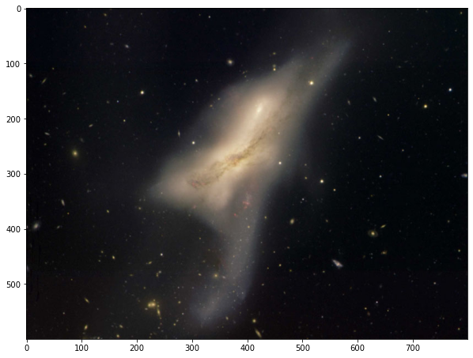

```python
import urllib.request
import cv2
import numpy as np
import matplotlib.pyplot as plt

def fetchAPOD(api_key, date, hd):
    URL_APOD = "https://api.nasa.gov/planetary/apod"
    params = {
      'api_key':api_key,
      'date':date,
      'hd': hd
    }
    response = requests.get(URL_APOD,params=params).json()
    pp.pprint(response)
    path2apod = response['url']
    #This is just to display the album covers in the output
    fig = plt.figure(figsize=(10,10))
    req = urllib.request.urlopen(path2apod)
    arr = np.asarray(bytearray(req.read()), dtype=np.uint8)
    img = cv2.imdecode(arr, -1) # 'Load it as it is'
    img = cv2.cvtColor(img, cv2.COLOR_BGR2RGB)
    plt.imshow(img)
    plt.show()
fetchAPOD(api_key, '2005-09-12', 'True')
```

I think I'll write a little project for fun to randomly generate an APOD sometime soon :]

Next, I'll look into the Asteroid Near Earth Objects (ANEO) API. This API only allows data to be collected over a maximum span of 7 days. However, we could readily extract more data by enclosing our queries in a for loop, similar to how it was done with Spotify.

```python
def fetchANEOWS(api_key,start_date,end_date):
    URL_NeoFeed = "https://api.nasa.gov/neo/rest/v1/feed"
    params = {
      'api_key':api_key,
      'start_date':start_date,
      'end_date':end_date
  }
    response = requests.get(URL_NeoFeed,params=params).json()
    pp.pprint(response)
    return response

aneo = fetchANEOWS(api_key,'2022-08-16','2022-08-17');
```

```
{'element_count': 27,
 'links': {'next': 'http://www.neowsapp.com/rest/v1/feed?start_date=2022-08-17&end_date=2022-08-18&detailed=false&api_key=uIuYlzCW70zB1F9oRcBUIIzhpM9m4V2neOwhn9iH',
           'prev': 'http://www.neowsapp.com/rest/v1/feed?start_date=2022-08-15&end_date=2022-08-16&detailed=false&api_key=uIuYlzCW70zB1F9oRcBUIIzhpM9m4V2neOwhn9iH',
           'self': 'http://www.neowsapp.com/rest/v1/feed?start_date=2022-08-16&end_date=2022-08-17&detailed=false&api_key=uIuYlzCW70zB1F9oRcBUIIzhpM9m4V2neOwhn9iH'},
 'near_earth_objects': {'2022-08-16': [{'absolute_magnitude_h': 18.05,
                                        'close_approach_data': [{'close_approach_date': '2022-08-16',
                                                                 'close_approach_date_full': '2022-Aug-16 '
                                                                                             '19:05',
                                                                 'epoch_date_close_approach': 1660676700000,
                                                                 'miss_distance': {'astronomical': '0.2238852542',
                                                                                   'kilometers': '33492757.152728554',
                                                                                   'lunar': '87.0913638838',
                                                                                   'miles': '20811434.2556758852'},
                                                                 'orbiting_body': 'Earth',
                                                                 'relative_velocity': {'kilometers_per_hour': '63921.2642544193',
                                                                                       'kilometers_per_second': '17.7559067373',
                                                                                       'miles_per_hour': '39718.1877807529'}}],
                                        'estimated_diameter': {'feet': {'estimated_diameter_max': 4786.5767834811,
                                                                        'estimated_diameter_min': 2140.6222134772},
                                                               'kilometers': {'estimated_diameter_max': 1.4589485569,
                                                                              'estimated_diameter_min': 0.6524616298},
                                                               'meters': {'estimated_diameter_max': 1458.9485569187,
                                                                          'estimated_diameter_min': 652.4616297891},
                                                               'miles': {'estimated_diameter_max': 0.9065483238,
                                                                         'estimated_diameter_min': 0.4054207354}},
                                        'id': '2159928',
                                        'is_potentially_hazardous_asteroid': False,
                                        'is_sentry_object': False,
                                        'links': {'self': 'http://www.neowsapp.com/rest/v1/neo/2159928?api_key=uIuYlzCW70zB1F9oRcBUIIzhpM9m4V2neOwhn9iH'},
                                        'name': '159928 (2005 CV69)',
                                        'nasa_jpl_url': 'http://ssd.jpl.nasa.gov/sbdb.cgi?sstr=2159928',
                                        'neo_reference_id': '2159928'},
                                       {'absolute_magnitude_h': 20.29,
                                        'close_approach_data': [{'close_approach_date': '2022-08-16',
                                                                 'close_approach_date_full': '2022-Aug-16 '
                                                                                             '01:51',
                                                                 'epoch_date_close_approach': 1660614660000,
                                                                 'miss_distance': {'astronomical': '0.3948717663',
                                                                                   'kilometers': '59071975.161617781',
                                                                                   'lunar': '153.6051170907',
```

[output cut: 705 more lines]

```
                                        'estimated_diameter': {'feet': {'estimated_diameter_max': 106.1756748422,
                                                                        'estimated_diameter_min': 47.4832053008},
                                                               'kilometers': {'estimated_diameter_max': 0.0323623447,
                                                                              'estimated_diameter_min': 0.0144728805},
                                                               'meters': {'estimated_diameter_max': 32.3623446563,
                                                                          'estimated_diameter_min': 14.4728805126},
                                                               'miles': {'estimated_diameter_max': 0.0201090225,
                                                                         'estimated_diameter_min': 0.0089930282}},
                                        'id': '54265877',
                                        'is_potentially_hazardous_asteroid': False,
                                        'is_sentry_object': False,
                                        'links': {'self': 'http://www.neowsapp.com/rest/v1/neo/54265877?api_key=uIuYlzCW70zB1F9oRcBUIIzhpM9m4V2neOwhn9iH'},
                                        'name': '(2022 FM2)',
                                        'nasa_jpl_url': 'http://ssd.jpl.nasa.gov/sbdb.cgi?sstr=54265877',
                                        'neo_reference_id': '54265877'}]}}
```

Yikes! This is a pretty complicated looking nested json! The data we want is contained in the 'near_earth_objects' key. This key then maps to the dates we queried data for. I tried doing a simple flattening as well as normalizing the json data in order to put the data into a pandas dataframe but wasn't successful. However, the following function can be used to recursively look through our desired level.

```python
def flatten_json(nested_json: dict, exclude: list=['']) -> dict:
    """
    Flatten a list of nested dicts.
    """
    out = dict()
    def flatten(x: (list, dict, str), name: str='', exclude=exclude):
        if type(x) is dict:
            for a in x:
                if a not in exclude:
                    flatten(x[a], f'{name}{a}_')
        elif type(x) is list:
            i = 0
            for a in x:
                flatten(a, f'{name}{i}_')
                i += 1
        else:
            out[name[:-1]] = x

    flatten(nested_json)
    return out
```

The level we want is here

```python
aneo['near_earth_objects']['2022-08-17'];
```

Then we can make our data frame by applying the function above in order to obtain the result below :]

```python
df = pd.DataFrame([flatten_json(x) for x in aneo['near_earth_objects']['2022-08-17']])
df
```

|  | links_self | id | neo_reference_id | name | nasa_jpl_url | absolute_magnitude_h | estimated_diameter_kilometers_estimated_diameter_min | estimated_diameter_kilometers_estimated_diameter_max | estimated_diameter_meters_estimated_diameter_min | estimated_diameter_meters_estimated_diameter_max | ... | close_approach_data_0_epoch_date_close_approach | close_approach_data_0_relative_velocity_kilometers_per_second | close_approach_data_0_relative_velocity_kilometers_per_hour | close_approach_data_0_relative_velocity_miles_per_hour | close_approach_data_0_miss_distance_astronomical | close_approach_data_0_miss_distance_lunar | close_approach_data_0_miss_distance_kilometers | close_approach_data_0_miss_distance_miles | close_approach_data_0_orbiting_body | is_sentry_object |
| --- | --- | --- | --- | --- | --- | --- | --- | --- | --- | --- | --- | --- | --- | --- | --- | --- | --- | --- | --- | --- | --- |
| 0 | http://www.neowsapp.com/rest/v1/neo/2285638?ap... | 2285638 | 2285638 | 285638 (2000 SO10) | http://ssd.jpl.nasa.gov/sbdb.cgi?sstr=2285638 | 17.53 | 0.829001 | 1.853702 | 829.000851 | 1853.702257 | ... | 1660777560000 | 21.6193413097 | 77829.6287147987 | 48360.3045755925 | 0.4753897322 | 184.9266058258 | 71117291.356990414 | 44190235.7207751532 | Earth | False |
| 1 | http://www.neowsapp.com/rest/v1/neo/3330687?ap... | 3330687 | 3330687 | (2006 HU50) | http://ssd.jpl.nasa.gov/sbdb.cgi?sstr=3330687 | 24.70 | 0.030518 | 0.068240 | 30.517923 | 68.240151 | ... | 1660721580000 | 12.8345824666 | 46204.4968798295 | 28709.6775195807 | 0.2738866136 | 106.5418926904 | 40972854.016073032 | 25459350.9197985616 | Earth | False |
| 2 | http://www.neowsapp.com/rest/v1/neo/3532394?ap... | 3532394 | 3532394 | (2010 MP1) | http://ssd.jpl.nasa.gov/sbdb.cgi?sstr=3532394 | 21.40 | 0.139494 | 0.311918 | 139.493823 | 311.917671 | ... | 1660725960000 | 12.6446138738 | 45520.6099457225 | 28284.7367743296 | 0.390291961 | 151.823572829 | 58386846.04372307 | 36279903.810075566 | Earth | False |
| 3 | http://www.neowsapp.com/rest/v1/neo/3690061?ap... | 3690061 | 3690061 | (2014 SH144) | http://ssd.jpl.nasa.gov/sbdb.cgi?sstr=3690061 | 25.00 | 0.026580 | 0.059435 | 26.580000 | 59.434687 | ... | 1660716900000 | 12.611330367 | 45400.7893213213 | 28210.2848980177 | 0.4146458219 | 161.2972247191 | 62030131.760639353 | 38543736.5792469514 | Earth | False |
| 4 | http://www.neowsapp.com/rest/v1/neo/3714001?ap... | 3714001 | 3714001 | (2015 FN35) | http://ssd.jpl.nasa.gov/sbdb.cgi?sstr=3714001 | 23.70 | 0.048368 | 0.108153 | 48.367649 | 108.153351 | ... | 1660732440000 | 10.8605045101 | 39097.8162363992 | 24293.8625386671 | 0.0529267402 | 20.5885019378 | 7917727.599963374 | 4919847.7942436012 | Earth | False |
| 5 | http://www.neowsapp.com/rest/v1/neo/3744834?ap... | 3744834 | 3744834 | (2016 DW1) | http://ssd.jpl.nasa.gov/sbdb.cgi?sstr=3744834 | 25.90 | 0.017561 | 0.039268 | 17.561232 | 39.268108 | ... | 1660717860000 | 16.3667287052 | 58920.2233387679 | 36610.7354406916 | 0.3409988372 | 132.6485476708 | 51012699.717596764 | 31697821.7569887832 | Earth | False |
| 6 | http://www.neowsapp.com/rest/v1/neo/3797908?ap... | 3797908 | 3797908 | (2018 BK5) | http://ssd.jpl.nasa.gov/sbdb.cgi?sstr=3797908 | 23.10 | 0.063761 | 0.142574 | 63.760979 | 142.573883 | ... | 1660713480000 | 15.2860846594 | 55029.9047739469 | 34193.4427746783 | 0.4633320661 | 180.2361737129 | 69313490.191259207 | 43069405.6499707766 | Earth | False |
| 7 | http://www.neowsapp.com/rest/v1/neo/3825100?ap... | 3825100 | 3825100 | (2018 LC1) | http://ssd.jpl.nasa.gov/sbdb.cgi?sstr=3825100 | 24.90 | 0.027833 | 0.062236 | 27.832677 | 62.235757 | ... | 1660712280000 | 6.5806137697 | 23690.2095709795 | 14720.1749414789 | 0.3892544769 | 151.4199915141 | 58231640.632204203 | 36183463.6393478814 | Earth | False |
| 8 | http://www.neowsapp.com/rest/v1/neo/54048888?a... | 54048888 | 54048888 | (2020 OK1) | http://ssd.jpl.nasa.gov/sbdb.cgi?sstr=54048888 | 23.90 | 0.044112 | 0.098637 | 44.111820 | 98.637028 | ... | 1660717500000 | 7.2317107133 | 26034.1585677636 | 16176.6136945085 | 0.1938562821 | 75.4100937369 | 29000486.888279127 | 18020066.9507688726 | Earth | False |
| 9 | http://www.neowsapp.com/rest/v1/neo/54053722?a... | 54053722 | 54053722 | (2020 RC) | http://ssd.jpl.nasa.gov/sbdb.cgi?sstr=54053722 | 22.00 | 0.105817 | 0.236614 | 105.816886 | 236.613750 | ... | 1660751340000 | 22.0650199131 | 79434.0716872817 | 49357.243043689 | 0.3826928775 | 148.8675293475 | 57250039.338170925 | 35573524.878471765 | Earth | False |
| 10 | http://www.neowsapp.com/rest/v1/neo/54123272?a... | 54123272 | 54123272 | (2021 DC1) | http://ssd.jpl.nasa.gov/sbdb.cgi?sstr=54123272 | 26.24 | 0.015016 | 0.033577 | 15.016025 | 33.576852 | ... | 1660775640000 | 6.9126875471 | 24885.6751694751 | 15462.9907740552 | 0.0924481569 | 35.9623330341 | 13830047.357665803 | 8593592.9378539614 | Earth | False |
| 11 | http://www.neowsapp.com/rest/v1/neo/54265632?a... | 54265632 | 54265632 | (2022 FR1) | http://ssd.jpl.nasa.gov/sbdb.cgi?sstr=54265632 | 28.12 | 0.006318 | 0.014127 | 6.317641 | 14.126676 | ... | 1660779360000 | 5.5363209356 | 19930.7553682022 | 12384.1963008699 | 0.4323786926 | 168.1953114214 | 64682931.446344762 | 40192109.8678592356 | Earth | False |
| 12 | http://www.neowsapp.com/rest/v1/neo/54265877?a... | 54265877 | 54265877 | (2022 FM2) | http://ssd.jpl.nasa.gov/sbdb.cgi?sstr=54265877 | 26.32 | 0.014473 | 0.032362 | 14.472881 | 32.362345 | ... | 1660746900000 | 6.7095921222 | 24154.531639754 | 15008.6866180461 | 0.1988044094 | 77.3349152566 | 29740716.192847978 | 18480024.1121309764 | Earth | False |

13 rows × 27 columns

As I did this it hit me... why don't I simply loop over the json starting at this level? So I loaded the json file starting at that level and... voila!

```python
aneo_df = pd.DataFrame(aneo['near_earth_objects']['2022-08-17'])
aneo_df
```

|  | links | id | neo_reference_id | name | nasa_jpl_url | absolute_magnitude_h | estimated_diameter | is_potentially_hazardous_asteroid | close_approach_data | is_sentry_object |
| --- | --- | --- | --- | --- | --- | --- | --- | --- | --- | --- |
| 0 | {'self': 'http://www.neowsapp.com/rest/v1/neo/... | 2285638 | 2285638 | 285638 (2000 SO10) | http://ssd.jpl.nasa.gov/sbdb.cgi?sstr=2285638 | 17.53 | {'kilometers': {'estimated_diameter_min': 0.82... | False | [{'close_approach_date': '2022-08-17', 'close_... | False |
| 1 | {'self': 'http://www.neowsapp.com/rest/v1/neo/... | 3330687 | 3330687 | (2006 HU50) | http://ssd.jpl.nasa.gov/sbdb.cgi?sstr=3330687 | 24.70 | {'kilometers': {'estimated_diameter_min': 0.03... | False | [{'close_approach_date': '2022-08-17', 'close_... | False |
| 2 | {'self': 'http://www.neowsapp.com/rest/v1/neo/... | 3532394 | 3532394 | (2010 MP1) | http://ssd.jpl.nasa.gov/sbdb.cgi?sstr=3532394 | 21.40 | {'kilometers': {'estimated_diameter_min': 0.13... | False | [{'close_approach_date': '2022-08-17', 'close_... | False |
| 3 | {'self': 'http://www.neowsapp.com/rest/v1/neo/... | 3690061 | 3690061 | (2014 SH144) | http://ssd.jpl.nasa.gov/sbdb.cgi?sstr=3690061 | 25.00 | {'kilometers': {'estimated_diameter_min': 0.02... | False | [{'close_approach_date': '2022-08-17', 'close_... | False |
| 4 | {'self': 'http://www.neowsapp.com/rest/v1/neo/... | 3714001 | 3714001 | (2015 FN35) | http://ssd.jpl.nasa.gov/sbdb.cgi?sstr=3714001 | 23.70 | {'kilometers': {'estimated_diameter_min': 0.04... | False | [{'close_approach_date': '2022-08-17', 'close_... | False |
| 5 | {'self': 'http://www.neowsapp.com/rest/v1/neo/... | 3744834 | 3744834 | (2016 DW1) | http://ssd.jpl.nasa.gov/sbdb.cgi?sstr=3744834 | 25.90 | {'kilometers': {'estimated_diameter_min': 0.01... | False | [{'close_approach_date': '2022-08-17', 'close_... | False |
| 6 | {'self': 'http://www.neowsapp.com/rest/v1/neo/... | 3797908 | 3797908 | (2018 BK5) | http://ssd.jpl.nasa.gov/sbdb.cgi?sstr=3797908 | 23.10 | {'kilometers': {'estimated_diameter_min': 0.06... | False | [{'close_approach_date': '2022-08-17', 'close_... | False |
| 7 | {'self': 'http://www.neowsapp.com/rest/v1/neo/... | 3825100 | 3825100 | (2018 LC1) | http://ssd.jpl.nasa.gov/sbdb.cgi?sstr=3825100 | 24.90 | {'kilometers': {'estimated_diameter_min': 0.02... | False | [{'close_approach_date': '2022-08-17', 'close_... | False |
| 8 | {'self': 'http://www.neowsapp.com/rest/v1/neo/... | 54048888 | 54048888 | (2020 OK1) | http://ssd.jpl.nasa.gov/sbdb.cgi?sstr=54048888 | 23.90 | {'kilometers': {'estimated_diameter_min': 0.04... | False | [{'close_approach_date': '2022-08-17', 'close_... | False |
| 9 | {'self': 'http://www.neowsapp.com/rest/v1/neo/... | 54053722 | 54053722 | (2020 RC) | http://ssd.jpl.nasa.gov/sbdb.cgi?sstr=54053722 | 22.00 | {'kilometers': {'estimated_diameter_min': 0.10... | True | [{'close_approach_date': '2022-08-17', 'close_... | False |
| 10 | {'self': 'http://www.neowsapp.com/rest/v1/neo/... | 54123272 | 54123272 | (2021 DC1) | http://ssd.jpl.nasa.gov/sbdb.cgi?sstr=54123272 | 26.24 | {'kilometers': {'estimated_diameter_min': 0.01... | False | [{'close_approach_date': '2022-08-17', 'close_... | False |
| 11 | {'self': 'http://www.neowsapp.com/rest/v1/neo/... | 54265632 | 54265632 | (2022 FR1) | http://ssd.jpl.nasa.gov/sbdb.cgi?sstr=54265632 | 28.12 | {'kilometers': {'estimated_diameter_min': 0.00... | False | [{'close_approach_date': '2022-08-17', 'close_... | False |
| 12 | {'self': 'http://www.neowsapp.com/rest/v1/neo/... | 54265877 | 54265877 | (2022 FM2) | http://ssd.jpl.nasa.gov/sbdb.cgi?sstr=54265877 | 26.32 | {'kilometers': {'estimated_diameter_min': 0.01... | False | [{'close_approach_date': '2022-08-17', 'close_... | False |

The data there is for just one day. But now we can easily loop through the days and concatenate our dataframes! I only did a query for two days so my date list is as follows

```python
date_list = ['2022-08-17','2022-08-16']

tot_aneo_list = []
for date in date_list:
    aneo_df = pd.DataFrame(aneo['near_earth_objects'][date])
    tot_aneo_list.append(aneo_df)

aneo_tot_df = pd.concat(tot_aneo_list, ignore_index = True)
aneo_tot_df
```

|  | links | id | neo_reference_id | name | nasa_jpl_url | absolute_magnitude_h | estimated_diameter | is_potentially_hazardous_asteroid | close_approach_data | is_sentry_object |
| --- | --- | --- | --- | --- | --- | --- | --- | --- | --- | --- |
| 0 | {'self': 'http://www.neowsapp.com/rest/v1/neo/... | 2285638 | 2285638 | 285638 (2000 SO10) | http://ssd.jpl.nasa.gov/sbdb.cgi?sstr=2285638 | 17.53 | {'kilometers': {'estimated_diameter_min': 0.82... | False | [{'close_approach_date': '2022-08-17', 'close_... | False |
| 1 | {'self': 'http://www.neowsapp.com/rest/v1/neo/... | 3330687 | 3330687 | (2006 HU50) | http://ssd.jpl.nasa.gov/sbdb.cgi?sstr=3330687 | 24.70 | {'kilometers': {'estimated_diameter_min': 0.03... | False | [{'close_approach_date': '2022-08-17', 'close_... | False |
| 2 | {'self': 'http://www.neowsapp.com/rest/v1/neo/... | 3532394 | 3532394 | (2010 MP1) | http://ssd.jpl.nasa.gov/sbdb.cgi?sstr=3532394 | 21.40 | {'kilometers': {'estimated_diameter_min': 0.13... | False | [{'close_approach_date': '2022-08-17', 'close_... | False |
| 3 | {'self': 'http://www.neowsapp.com/rest/v1/neo/... | 3690061 | 3690061 | (2014 SH144) | http://ssd.jpl.nasa.gov/sbdb.cgi?sstr=3690061 | 25.00 | {'kilometers': {'estimated_diameter_min': 0.02... | False | [{'close_approach_date': '2022-08-17', 'close_... | False |
| 4 | {'self': 'http://www.neowsapp.com/rest/v1/neo/... | 3714001 | 3714001 | (2015 FN35) | http://ssd.jpl.nasa.gov/sbdb.cgi?sstr=3714001 | 23.70 | {'kilometers': {'estimated_diameter_min': 0.04... | False | [{'close_approach_date': '2022-08-17', 'close_... | False |
| 5 | {'self': 'http://www.neowsapp.com/rest/v1/neo/... | 3744834 | 3744834 | (2016 DW1) | http://ssd.jpl.nasa.gov/sbdb.cgi?sstr=3744834 | 25.90 | {'kilometers': {'estimated_diameter_min': 0.01... | False | [{'close_approach_date': '2022-08-17', 'close_... | False |
| 6 | {'self': 'http://www.neowsapp.com/rest/v1/neo/... | 3797908 | 3797908 | (2018 BK5) | http://ssd.jpl.nasa.gov/sbdb.cgi?sstr=3797908 | 23.10 | {'kilometers': {'estimated_diameter_min': 0.06... | False | [{'close_approach_date': '2022-08-17', 'close_... | False |
| 7 | {'self': 'http://www.neowsapp.com/rest/v1/neo/... | 3825100 | 3825100 | (2018 LC1) | http://ssd.jpl.nasa.gov/sbdb.cgi?sstr=3825100 | 24.90 | {'kilometers': {'estimated_diameter_min': 0.02... | False | [{'close_approach_date': '2022-08-17', 'close_... | False |
| 8 | {'self': 'http://www.neowsapp.com/rest/v1/neo/... | 54048888 | 54048888 | (2020 OK1) | http://ssd.jpl.nasa.gov/sbdb.cgi?sstr=54048888 | 23.90 | {'kilometers': {'estimated_diameter_min': 0.04... | False | [{'close_approach_date': '2022-08-17', 'close_... | False |
| 9 | {'self': 'http://www.neowsapp.com/rest/v1/neo/... | 54053722 | 54053722 | (2020 RC) | http://ssd.jpl.nasa.gov/sbdb.cgi?sstr=54053722 | 22.00 | {'kilometers': {'estimated_diameter_min': 0.10... | True | [{'close_approach_date': '2022-08-17', 'close_... | False |
| 10 | {'self': 'http://www.neowsapp.com/rest/v1/neo/... | 54123272 | 54123272 | (2021 DC1) | http://ssd.jpl.nasa.gov/sbdb.cgi?sstr=54123272 | 26.24 | {'kilometers': {'estimated_diameter_min': 0.01... | False | [{'close_approach_date': '2022-08-17', 'close_... | False |
| 11 | {'self': 'http://www.neowsapp.com/rest/v1/neo/... | 54265632 | 54265632 | (2022 FR1) | http://ssd.jpl.nasa.gov/sbdb.cgi?sstr=54265632 | 28.12 | {'kilometers': {'estimated_diameter_min': 0.00... | False | [{'close_approach_date': '2022-08-17', 'close_... | False |
| 12 | {'self': 'http://www.neowsapp.com/rest/v1/neo/... | 54265877 | 54265877 | (2022 FM2) | http://ssd.jpl.nasa.gov/sbdb.cgi?sstr=54265877 | 26.32 | {'kilometers': {'estimated_diameter_min': 0.01... | False | [{'close_approach_date': '2022-08-17', 'close_... | False |
| 13 | {'self': 'http://www.neowsapp.com/rest/v1/neo/... | 2159928 | 2159928 | 159928 (2005 CV69) | http://ssd.jpl.nasa.gov/sbdb.cgi?sstr=2159928 | 18.05 | {'kilometers': {'estimated_diameter_min': 0.65... | False | [{'close_approach_date': '2022-08-16', 'close_... | False |
| 14 | {'self': 'http://www.neowsapp.com/rest/v1/neo/... | 2445974 | 2445974 | 445974 (2013 BJ18) | http://ssd.jpl.nasa.gov/sbdb.cgi?sstr=2445974 | 20.29 | {'kilometers': {'estimated_diameter_min': 0.23... | True | [{'close_approach_date': '2022-08-16', 'close_... | False |
| 15 | {'self': 'http://www.neowsapp.com/rest/v1/neo/... | 3290881 | 3290881 | (2005 SQ) | http://ssd.jpl.nasa.gov/sbdb.cgi?sstr=3290881 | 20.20 | {'kilometers': {'estimated_diameter_min': 0.24... | True | [{'close_approach_date': '2022-08-16', 'close_... | False |
| 16 | {'self': 'http://www.neowsapp.com/rest/v1/neo/... | 3560817 | 3560817 | (2011 FS29) | http://ssd.jpl.nasa.gov/sbdb.cgi?sstr=3560817 | 22.60 | {'kilometers': {'estimated_diameter_min': 0.08... | False | [{'close_approach_date': '2022-08-16', 'close_... | False |
| 17 | {'self': 'http://www.neowsapp.com/rest/v1/neo/... | 3723955 | 3723955 | (2015 NK3) | http://ssd.jpl.nasa.gov/sbdb.cgi?sstr=3723955 | 21.30 | {'kilometers': {'estimated_diameter_min': 0.14... | False | [{'close_approach_date': '2022-08-16', 'close_... | False |
| 18 | {'self': 'http://www.neowsapp.com/rest/v1/neo/... | 3778647 | 3778647 | (2017 OR18) | http://ssd.jpl.nasa.gov/sbdb.cgi?sstr=3778647 | 21.30 | {'kilometers': {'estimated_diameter_min': 0.14... | False | [{'close_approach_date': '2022-08-16', 'close_... | False |
| 19 | {'self': 'http://www.neowsapp.com/rest/v1/neo/... | 3799743 | 3799743 | (2018 DT1) | http://ssd.jpl.nasa.gov/sbdb.cgi?sstr=3799743 | 21.10 | {'kilometers': {'estimated_diameter_min': 0.16... | False | [{'close_approach_date': '2022-08-16', 'close_... | False |
| 20 | {'self': 'http://www.neowsapp.com/rest/v1/neo/... | 3826623 | 3826623 | (2018 PV7) | http://ssd.jpl.nasa.gov/sbdb.cgi?sstr=3826623 | 24.20 | {'kilometers': {'estimated_diameter_min': 0.03... | False | [{'close_approach_date': '2022-08-16', 'close_... | False |
| 21 | {'self': 'http://www.neowsapp.com/rest/v1/neo/... | 3843359 | 3843359 | (2019 OH1) | http://ssd.jpl.nasa.gov/sbdb.cgi?sstr=3843359 | 22.61 | {'kilometers': {'estimated_diameter_min': 0.07... | False | [{'close_approach_date': '2022-08-16', 'close_... | False |
| 22 | {'self': 'http://www.neowsapp.com/rest/v1/neo/... | 54050972 | 54050972 | (2020 OC7) | http://ssd.jpl.nasa.gov/sbdb.cgi?sstr=54050972 | 20.80 | {'kilometers': {'estimated_diameter_min': 0.18... | False | [{'close_approach_date': '2022-08-16', 'close_... | False |
| 23 | {'self': 'http://www.neowsapp.com/rest/v1/neo/... | 54075323 | 54075323 | (2020 TN8) | http://ssd.jpl.nasa.gov/sbdb.cgi?sstr=54075323 | 20.60 | {'kilometers': {'estimated_diameter_min': 0.20... | False | [{'close_approach_date': '2022-08-16', 'close_... | False |
| 24 | {'self': 'http://www.neowsapp.com/rest/v1/neo/... | 54106530 | 54106530 | (2021 BP1) | http://ssd.jpl.nasa.gov/sbdb.cgi?sstr=54106530 | 29.60 | {'kilometers': {'estimated_diameter_min': 0.00... | False | [{'close_approach_date': '2022-08-16', 'close_... | False |
| 25 | {'self': 'http://www.neowsapp.com/rest/v1/neo/... | 54247854 | 54247854 | (2016 FL60) | http://ssd.jpl.nasa.gov/sbdb.cgi?sstr=54247854 | 23.92 | {'kilometers': {'estimated_diameter_min': 0.04... | False | [{'close_approach_date': '2022-08-16', 'close_... | False |
| 26 | {'self': 'http://www.neowsapp.com/rest/v1/neo/... | 54248345 | 54248345 | (2022 DN1) | http://ssd.jpl.nasa.gov/sbdb.cgi?sstr=54248345 | 26.32 | {'kilometers': {'estimated_diameter_min': 0.01... | False | [{'close_approach_date': '2022-08-16', 'close_... | False |

Sweet! Now we have this data ready to do more analysis on which I will do something with in a future post :]

## Getting Weather Data from National Weather Service

The National Weather Service (NWS) API gives us access to forecasts, alerts, and observations, and other weather data. You can get more information about the data you can collect here: https://weather-gov.github.io/api/general-faqs

To get a forecast reading, we need to 3 things:

- NWS Office name which we can get from here: https://www.weather.gov/srh/nwsoffices
- latitude of location we want a forecast for
- longitude of location we want a forecast for

The base URL for a forecase reading looks as follows:

`https://api.weather.gov/gridpoints/{office}/{grid X},{grid Y}/forecast`

For this example, I'll show how to get the weather forecast for New York City. The latitude and longitude of NYC are 40.7128° N, 74.0060° W.

```python
grid_X = '40.730610'
grid_Y = '-73.935242'
url = f'https://api.weather.gov/points/{grid_X},{grid_Y}'
rmd = requests.get(url)
rmd = rmd.json()
#rmd
```

Now that we have the metadata for NYC we can get information about the forecast using the URL provided in the json. So let's do that.

```python
url = 'https://api.weather.gov/gridpoints/OKX/35,35/forecast'
nyc_forecast_request = requests.get(url)
nyc_forecast_request
nyc_forecast = nyc_forecast_request.json()
#nyc_forecast
```

What do you know... another nested json dataset. No problem though! The data we want is within at the `periods` level so we just have to set that for our DataFrame entry and now we have our weekly forecast placed nicely in a pandas dataframe! :]

```python
nyc_fc_df = pd.json_normalize(nyc_forecast['properties']['periods'])
nyc_fc_df
```

|  | number | name | startTime | endTime | isDaytime | temperature | temperatureUnit | temperatureTrend | windSpeed | windDirection | icon | shortForecast | detailedForecast |
| --- | --- | --- | --- | --- | --- | --- | --- | --- | --- | --- | --- | --- | --- |
| 0 | 1 | Tonight | 2022-08-18T22:00:00-04:00 | 2022-08-19T06:00:00-04:00 | False | 73 | F | None | 3 to 7 mph | W | https://api.weather.gov/icons/land/night/few?s... | Mostly Clear | Mostly clear, with a low around 73. West wind ... |
| 1 | 2 | Friday | 2022-08-19T06:00:00-04:00 | 2022-08-19T18:00:00-04:00 | True | 89 | F | None | 5 to 12 mph | SW | https://api.weather.gov/icons/land/day/sct?siz... | Mostly Sunny | Mostly sunny, with a high near 89. Southwest w... |
| 2 | 3 | Friday Night | 2022-08-19T18:00:00-04:00 | 2022-08-20T06:00:00-04:00 | False | 74 | F | None | 5 to 12 mph | SW | https://api.weather.gov/icons/land/night/sct?s... | Partly Cloudy | Partly cloudy, with a low around 74. Southwest... |
| 3 | 4 | Saturday | 2022-08-20T06:00:00-04:00 | 2022-08-20T18:00:00-04:00 | True | 86 | F | falling | 2 to 13 mph | S | https://api.weather.gov/icons/land/day/bkn?siz... | Partly Sunny | Partly sunny. High near 86, with temperatures ... |
| 4 | 5 | Saturday Night | 2022-08-20T18:00:00-04:00 | 2022-08-21T06:00:00-04:00 | False | 71 | F | rising | 3 to 12 mph | SE | https://api.weather.gov/icons/land/night/sct?s... | Partly Cloudy | Partly cloudy. Low around 71, with temperature... |
| 5 | 6 | Sunday | 2022-08-21T06:00:00-04:00 | 2022-08-21T18:00:00-04:00 | True | 85 | F | falling | 3 to 12 mph | SE | https://api.weather.gov/icons/land/day/bkn/rai... | Partly Sunny then Slight Chance Rain Showers | A slight chance of rain showers after 2pm. Par... |
| 6 | 7 | Sunday Night | 2022-08-21T18:00:00-04:00 | 2022-08-22T06:00:00-04:00 | False | 72 | F | None | 3 to 10 mph | SE | https://api.weather.gov/icons/land/night/rain_... | Chance Rain Showers | A chance of rain showers. Mostly cloudy, with ... |
| 7 | 8 | Monday | 2022-08-22T06:00:00-04:00 | 2022-08-22T18:00:00-04:00 | True | 82 | F | None | 3 to 8 mph | SE | https://api.weather.gov/icons/land/day/rain_sh... | Showers And Thunderstorms Likely | A chance of rain showers before 2pm, then show... |
| 8 | 9 | Monday Night | 2022-08-22T18:00:00-04:00 | 2022-08-23T06:00:00-04:00 | False | 71 | F | None | 2 to 7 mph | SW | https://api.weather.gov/icons/land/night/tsra_... | Showers And Thunderstorms Likely | Showers and thunderstorms likely. Mostly cloud... |
| 9 | 10 | Tuesday | 2022-08-23T06:00:00-04:00 | 2022-08-23T18:00:00-04:00 | True | 84 | F | None | 2 to 9 mph | W | https://api.weather.gov/icons/land/day/rain_sh... | Chance Rain Showers | A chance of rain showers before 2pm, then a ch... |
| 10 | 11 | Tuesday Night | 2022-08-23T18:00:00-04:00 | 2022-08-24T06:00:00-04:00 | False | 71 | F | None | 3 to 8 mph | SW | https://api.weather.gov/icons/land/night/tsra_... | Chance Showers And Thunderstorms then Slight C... | A chance of showers and thunderstorms before 8... |
| 11 | 12 | Wednesday | 2022-08-24T06:00:00-04:00 | 2022-08-24T18:00:00-04:00 | True | 87 | F | None | 5 to 9 mph | W | https://api.weather.gov/icons/land/day/sct/rai... | Mostly Sunny then Slight Chance Rain Showers | A slight chance of rain showers after 2pm. Mos... |
| 12 | 13 | Wednesday Night | 2022-08-24T18:00:00-04:00 | 2022-08-25T06:00:00-04:00 | False | 72 | F | None | 3 to 9 mph | SW | https://api.weather.gov/icons/land/night/rain_... | Slight Chance Rain Showers then Partly Cloudy | A slight chance of rain showers before 8pm. Pa... |
| 13 | 14 | Thursday | 2022-08-25T06:00:00-04:00 | 2022-08-25T18:00:00-04:00 | True | 88 | F | None | 3 to 10 mph | W | https://api.weather.gov/icons/land/day/sct?siz... | Mostly Sunny | Mostly sunny, with a high near 88. |

## Getting Earthquake Data from USGS

In this section I'll show how to get data from the United States Geological Survey (USGS) API. From the USGS we can get earthquake information. You can find the documentation for the API here: https://earthquake.usgs.gov/fdsnws/event/1/?ref=springboard

The URL has the following basic structure: `https://earthquake.usgs.gov/fdsnws/event/1/[METHOD[?PARAMETERS]]`

We'll be requesting the METHOD to be `format=geojason` in order to return a json file. There are options to get your data as a csv, xml, and plain text too though.

The parameters can return help refine our query by providing information regarding the time, desired location and many others for earthquake data.

Let's start by seeing what kind of information we can extract. I'm not displaying the ouput because it's really long.

```python
url = 'https://earthquake.usgs.gov/fdsnws/event/1/application.json'
r = requests.get(url)
r = r.json()
```

Interesting! There's stuff about volcanic events, nuclear explosions, rock slides and even meteorites! Let's find out how many requests we can make

```python
url = 'https://earthquake.usgs.gov/fdsnws/event/1/count?format=geojson'
r = requests.get(url)
r = r.json()
r
```

```
{'count': 8868, 'maxAllowed': 20000}
```

```python
start ='2014-01-01'
end = '2014-01-02'
url = f'https://earthquake.usgs.gov/fdsnws/event/1/query?format=geojson&starttime={start}&endtime={end}'
r = requests.get(url)
r = r.json()
```

We have data! Let's get this into a dataframe!

```python
earthquake_df = pd.json_normalize(r['features'])
earthquake_df
```

|  | type | id | properties.mag | properties.place | properties.time | properties.updated | properties.tz | properties.url | properties.detail | properties.felt | ... | properties.types | properties.nst | properties.dmin | properties.rms | properties.gap | properties.magType | properties.type | properties.title | geometry.type | geometry.coordinates |
| --- | --- | --- | --- | --- | --- | --- | --- | --- | --- | --- | --- | --- | --- | --- | --- | --- | --- | --- | --- | --- | --- |
| 0 | Feature | ci11408890 | 1.29 | 10km SSW of Idyllwild, CA | 1388620296020 | 1457728844428 | None | https://earthquake.usgs.gov/earthquakes/eventp... | https://earthquake.usgs.gov/fdsnws/event/1/que... | NaN | ... | ,cap,focal-mechanism,nearby-cities,origin,phas... | 39.0 | 0.067290 | 0.09 | 51.0 | ml | earthquake | M 1.3 - 10km SSW of Idyllwild, CA | Point | [-116.7776667, 33.6633333, 11.008] |
| 1 | Feature | ak01421ig3u | 1.10 | Central Alaska | 1388620046501 | 1558392330681 | None | https://earthquake.usgs.gov/earthquakes/eventp... | https://earthquake.usgs.gov/fdsnws/event/1/que... | NaN | ... | ,associate,origin,phase-data, | NaN | NaN | 0.57 | NaN | ml | earthquake | M 1.1 - Central Alaska | Point | [-151.6459, 63.102, 14.1] |
| 2 | Feature | ak01421i2zj | 1.20 | 7 km SSW of Big Lake, Alaska | 1388619956476 | 1558392330249 | None | https://earthquake.usgs.gov/earthquakes/eventp... | https://earthquake.usgs.gov/fdsnws/event/1/que... | NaN | ... | ,associate,cap,origin,phase-data, | NaN | NaN | 0.47 | NaN | ml | earthquake | M 1.2 - 7 km SSW of Big Lake, Alaska | Point | [-150.0165, 61.4581, 44.6] |
| 3 | Feature | ak01421heui | 1.40 | 32 km N of Petersville, Alaska | 1388619763623 | 1558392329762 | None | https://earthquake.usgs.gov/earthquakes/eventp... | https://earthquake.usgs.gov/fdsnws/event/1/que... | NaN | ... | ,associate,origin,phase-data, | NaN | NaN | 0.35 | NaN | ml | earthquake | M 1.4 - 32 km N of Petersville, Alaska | Point | [-150.8276, 62.7884, 87.6] |
| 4 | Feature | usc000mnnn | 4.00 | 28 km WNW of Coquimbo, Chile | 1388619735000 | 1394151954000 | None | https://earthquake.usgs.gov/earthquakes/eventp... | https://earthquake.usgs.gov/fdsnws/event/1/que... | NaN | ... | ,origin,phase-data, | NaN | NaN | 3.09 | NaN | ml | earthquake | M 4.0 - 28 km WNW of Coquimbo, Chile | Point | [-71.621, -29.888, 40] |
| ... | ... | ... | ... | ... | ... | ... | ... | ... | ... | ... | ... | ... | ... | ... | ... | ... | ... | ... | ... | ... | ... |
| 321 | Feature | ak0141nol21 | 2.00 | 69 km ENE of Pedro Bay, Alaska | 1388535883771 | 1558392307098 | None | https://earthquake.usgs.gov/earthquakes/eventp... | https://earthquake.usgs.gov/fdsnws/event/1/que... | NaN | ... | ,associate,origin,phase-data, | NaN | NaN | 0.77 | NaN | ml | earthquake | M 2.0 - 69 km ENE of Pedro Bay, Alaska | Point | [-153.0185, 60.0872, 105.8] |
| 322 | Feature | nc72133841 | 0.57 | 10 km W of Cobb, California | 1388535010970 | 1486062277926 | None | https://earthquake.usgs.gov/earthquakes/eventp... | https://earthquake.usgs.gov/fdsnws/event/1/que... | NaN | ... | ,nearby-cities,origin,phase-data,scitech-link, | 30.0 | 0.007207 | 0.04 | 65.0 | md | earthquake | M 0.6 - 10 km W of Cobb, California | Point | [-122.8435, 38.8216667, 2.14] |
| 323 | Feature | uw60664271 | 2.20 | 1 km NW of Sweet Home, Oregon | 1388534755060 | 1469215315190 | None | https://earthquake.usgs.gov/earthquakes/eventp... | https://earthquake.usgs.gov/fdsnws/event/1/que... | NaN | ... | ,cap,origin,phase-data, | 4.0 | 0.115700 | 0.07 | 179.0 | md | explosion | M 2.2 Explosion - 1 km NW of Sweet Home, Oregon | Point | [-122.7498333, 44.408, -0.348] |
| 324 | Feature | usc000lv5j | 4.50 | 163 km W of Neiafu, Tonga | 1388534728830 | 1394151953000 | None | https://earthquake.usgs.gov/earthquakes/eventp... | https://earthquake.usgs.gov/fdsnws/event/1/que... | NaN | ... | ,cap,origin,phase-data, | NaN | 5.337000 | 0.60 | 41.0 | mb | earthquake | M 4.5 - 163 km W of Neiafu, Tonga | Point | [-175.5282, -18.4965, 217.9] |
| 325 | Feature | usc000lv5e | 5.10 | 76 km NNW of Davila, Philippines | 1388534476610 | 1394151953000 | None | https://earthquake.usgs.gov/earthquakes/eventp... | https://earthquake.usgs.gov/fdsnws/event/1/que... | NaN | ... | ,cap,origin,phase-data, | NaN | 3.794000 | 0.85 | 29.0 | mb | earthquake | M 5.1 - 76 km NNW of Davila, Philippines | Point | [120.2389, 19.0868, 10.07] |

326 rows × 30 columns

Awesome! More data to play with! Below is an example of how to run a query that has more specifications and that template could be used for even further refinments by adding more sections to the parameters string.

```python
def earthquake(f):
    parameters = {
        "format": "geojson",
        "starttime": "2020- 01-01",
        "endtime": "2020-12-31",
        "alertlevel": "orange"
    }
    data = requests.get(f, params = parameters)
    data = json.loads(data.text)
    return data

f = r"https://earthquake.usgs.gov/fdsnws/event/1/query?"
a = earthquake(f)
```

## Getting News from The New York Times

This API gives you access to an enormous amount of articles from the New York Times. Some of the data goes back all the way to 1851!

Here I'll show how to get different types of information like archives and movie reviews. You can get detailed information about the API usage here: https://developer.nytimes.com/apis

Let's start by getting the archive for the month of June and the year 2020. I won't print the ouput of this particular query because it's really long...

```python
year = '2020'
month = '6'
api_key = 'jhkMYAlxMsPPYrLatKFLwF6JbQLhME9V'
url = f'https://api.nytimes.com/svc/archive/v1/{year}/{month}.json?api-key={api_key}'

r = requests.get(url)
r = r.json()
```

We have a succesful request. Now let;s put it into a dataframe, which can be readily done using the json nesting method I've been using.

```python
nyt_df = pd.DataFrame(r['response']['docs'])
nyt_df
```

|  | abstract | web_url | snippet | lead_paragraph | source | multimedia | headline | keywords | pub_date | document_type | news_desk | section_name | byline | type_of_material | _id | word_count | uri | print_section | print_page | subsection_name |
| --- | --- | --- | --- | --- | --- | --- | --- | --- | --- | --- | --- | --- | --- | --- | --- | --- | --- | --- | --- | --- |
| 0 | So far, 47 police vehicles have been damaged. ... | https://www.nytimes.com/2020/05/31/nyregion/po... | So far, 47 police vehicles have been damaged. ... | On Friday night in the Fort Greene section of ... | The New York Times | [{'rank': 0, 'subtype': 'xlarge', 'caption': N... | {'main': 'Symbol of N.Y.C. Unrest: A Burning P... | [{'name': 'subject', 'value': 'Demonstrations,... | 2020-06-01T00:07:56+0000 | article | Metro | New York | {'original': 'By Azi Paybarah and Nikita Stewa... | News | nyt://article/3022efc6-c3a7-538e-9c33-9396be9a... | 808 | nyt://article/3022efc6-c3a7-538e-9c33-9396be9a... | NaN | NaN | NaN |
| 1 | The death of George Floyd at the hands of the ... | https://www.nytimes.com/video/us/1000000071654... | The death of George Floyd at the hands of the ... | The death of George Floyd at the hands of the ... | The New York Times | [{'rank': 0, 'subtype': 'xlarge', 'caption': N... | {'main': '‘We’re Sick and Tired’: Voices From ... | [{'name': 'persons', 'value': 'Floyd, George (... | 2020-06-01T00:08:23+0000 | multimedia |  | U.S. | {'original': 'By Katie G. Nelson, Mike Shum, S... | Video | nyt://video/d426a47f-812b-5fee-b0e0-75733d2e8543 | 0 | nyt://video/d426a47f-812b-5fee-b0e0-75733d2e8543 | NaN | NaN | NaN |
| 2 | The truck can be seen speeding toward proteste... | https://www.nytimes.com/video/us/1000000071663... | The truck can be seen speeding toward proteste... | The truck can be seen speeding toward proteste... | The New York Times | [{'rank': 0, 'subtype': 'xlarge', 'caption': N... | {'main': 'Video Appears to Show a Tanker Truck... | [{'name': 'subject', 'value': 'Demonstrations,... | 2020-06-01T00:22:27+0000 | multimedia |  | U.S. | {'original': 'By The New York Times', 'person'... | Video | nyt://video/2c42036b-8ef6-5ba5-8375-a85cb7deda40 | 0 | nyt://video/2c42036b-8ef6-5ba5-8375-a85cb7deda40 | NaN | NaN | NaN |
| 3 | In communities across the country, congregatio... | https://www.nytimes.com/2020/05/31/us/churches... | In communities across the country, congregatio... | SACRAMENTO — With their most vulnerable member... | The New York Times | [{'rank': 0, 'subtype': 'xlarge', 'caption': N... | {'main': 'Amid Riots and a Pandemic, Church At... | [{'name': 'subject', 'value': 'Churches (Build... | 2020-06-01T00:28:09+0000 | article | National | U.S. | {'original': 'By Shawn Hubler and Rick Rojas',... | News | nyt://article/eeb31381-63db-5bf0-8e56-c92b1bc2... | 1524 | nyt://article/eeb31381-63db-5bf0-8e56-c92b1bc2... | A | 14 | NaN |
| 4 | Videos showed officers using batons, tear gas,... | https://www.nytimes.com/2020/05/31/us/police-t... | Videos showed officers using batons, tear gas,... | [Follow our live updates on the George Floyd p... | The New York Times | [] | {'main': 'Facing Protests Over Use of Force, P... | [{'name': 'subject', 'value': 'George Floyd Pr... | 2020-06-01T00:45:13+0000 | article | National | U.S. | {'original': 'By Shaila Dewan and Mike Baker',... | News | nyt://article/25642b46-e875-56a1-b7fd-1be7c34a... | 1539 | nyt://article/25642b46-e875-56a1-b7fd-1be7c34a... | A | 1 | NaN |
| ... | ... | ... | ... | ... | ... | ... | ... | ... | ... | ... | ... | ... | ... | ... | ... | ... | ... | ... | ... | ... |
| 4487 |  | https://www.nytimes.com/interactive/2020/06/30... |  |  | The New York Times | [{'rank': 0, 'subtype': 'xlarge', 'caption': N... | {'main': 'Oklahoma Primary Election Results: F... | [{'name': 'subject', 'value': 'Elections', 'ra... | 2020-06-30T23:50:20+0000 | multimedia | U.S. | U.S. | {'original': '', 'person': [], 'organization':... |  | nyt://interactive/d954de2f-d0d3-5b03-a828-cb21... | 0 | nyt://interactive/d954de2f-d0d3-5b03-a828-cb21... | NaN | NaN | Elections |
| 4488 |  | https://www.nytimes.com/interactive/2020/06/30... |  |  | The New York Times | [{'rank': 0, 'subtype': 'xlarge', 'caption': N... | {'main': 'Colorado Primary Election Results: T... | [{'name': 'subject', 'value': 'Elections', 'ra... | 2020-06-30T23:50:20+0000 | multimedia | U.S. | U.S. | {'original': '', 'person': [], 'organization':... |  | nyt://interactive/f486d28b-555d-52ec-b069-fe5e... | 0 | nyt://interactive/f486d28b-555d-52ec-b069-fe5e... | NaN | NaN | Elections |
| 4489 |  | https://www.nytimes.com/interactive/2020/06/30... |  |  | The New York Times | [{'rank': 0, 'subtype': 'xlarge', 'caption': N... | {'main': 'Oklahoma U.S. Senate Primary Electio... | [{'name': 'subject', 'value': 'Elections', 'ra... | 2020-06-30T23:50:20+0000 | multimedia | U.S. | U.S. | {'original': '', 'person': [], 'organization':... |  | nyt://interactive/f501e742-e85e-52b6-bc00-ca8c... | 0 | nyt://interactive/f501e742-e85e-52b6-bc00-ca8c... | NaN | NaN | Elections |
| 4490 |  | https://www.nytimes.com/interactive/2020/06/30... |  |  | The New York Times | [{'rank': 0, 'subtype': 'xlarge', 'caption': N... | {'main': 'Oklahoma Primary Election Results: F... | [{'name': 'subject', 'value': 'Elections', 'ra... | 2020-06-30T23:50:20+0000 | multimedia | U.S. | U.S. | {'original': '', 'person': [], 'organization':... |  | nyt://interactive/fb8ae641-5cb6-552e-9be4-d73a... | 0 | nyt://interactive/fb8ae641-5cb6-552e-9be4-d73a... | NaN | NaN | Elections |
| 4491 | This file was published in error | https://www.nytimes.com/2020/06/30/theater/thi... | This file was published in error | This file was published in error | The New York Times | [{'rank': 0, 'subtype': 'xlarge', 'caption': N... | {'main': 'This file was published in error', '... | [{'name': 'subject', 'value': 'Theater', 'rank... | 2020-06-30T23:54:48+0000 | article | Culture | Theater | {'original': '', 'person': [], 'organization':... | News | nyt://article/7fc5a07f-d62c-523f-a1f1-8152bf02... | 6 | nyt://article/7fc5a07f-d62c-523f-a1f1-8152bf02... | NaN | NaN | NaN |

4492 rows × 20 columns

There is plenty of data cleanup that I can do on this dataset but that will be the subject of a different post.

```python
api_key = 'jhkMYAlxMsPPYrLatKFLwF6JbQLhME9V'
movie_title = 'matrix'
start_date = '1999-03-01'
end_date = '2003-12-31'
base_url = 'https://api.nytimes.com/svc/movies/v2/reviews/search.json?query='
search_url = base_url + f'{movie_title}&api-key={api_key}&opening-date={start_date}:{end_date}'
print(search_url)
r = requests.get(search_url)
r = r.json()
r
```

```
https://api.nytimes.com/svc/movies/v2/reviews/search.json?query=matrix&api-key=jhkMYAlxMsPPYrLatKFLwF6JbQLhME9V&opening-date=1999-03-01:2003-12-31
```

```
{'status': 'OK',
 'copyright': 'Copyright (c) 2022 The New York Times Company. All Rights Reserved.',
 'has_more': False,
 'num_results': 3,
 'results': [{'display_title': 'The Matrix Revolutions',
   'mpaa_rating': 'R',
   'critics_pick': 0,
   'byline': 'A. O. SCOTT',
   'headline': 'The Game Concludes With Light and Noise',
   'summary_short': '&quot;Everything that has a beginning has an end.&quot; Yes, thank God — or Neo, or the One, or the Source, or the Oracle, or the Architect, or whoever it was who set this metaphysical action trilogy in motion. &quot;Reloaded,&quot; the second installment, was overstuffed and un…
   'publication_date': '2003-11-05',
   'opening_date': '2003-11-05',
   'date_updated': '2017-11-02 04:18:03',
   'link': {'type': 'article',
    'url': 'https://www.nytimes.com/2003/11/05/movies/film-review-the-game-concludes-with-light-and-noise.html',
    'suggested_link_text': 'Read the New York Times Review of The Matrix Revolutions'},
   'multimedia': None},
  {'display_title': 'The Matrix Reloaded',
   'mpaa_rating': 'R',
   'critics_pick': 0,
   'byline': 'Elvis Mitchell',
   'headline': 'An Idealized World and a Troubled Hero',
   'summary_short': "The mastery of filmmaking hasn't abated in &quot;Reloaded&quot; — the Wachowskis are as suited to the task of guiding this sequel to their surprise 1999 hit as their unsure hero, Neo (Keanu Reeves), is to saving the world. Though the staging of the action sequences is as vicious…
   'publication_date': '2003-05-14',
   'opening_date': '2003-05-15',
   'date_updated': '2017-11-02 04:18:02',
   'link': {'type': 'article',
    'url': 'https://www.nytimes.com/2003/05/14/movies/film-review-an-idealized-world-and-a-troubled-hero.html',
    'suggested_link_text': 'Read the New York Times Review of The Matrix Reloaded'},
   'multimedia': None},
  {'display_title': 'The Matrix',
   'mpaa_rating': 'R',
   'critics_pick': 0,
   'byline': 'Janet Maslin',
   'headline': 'Matrix, The (Movie)  ',
   'summary_short': 'Hacker as action messiah. Enough visual bravado to sustain steady suspense. Cult classic, virtually speaking.',
   'publication_date': '1999-03-31',
   'opening_date': '1999-03-31',
   'date_updated': '2017-11-02 04:17:57',
   'link': {'type': 'article',
    'url': 'https://www.nytimes.com/1999/03/31/movies/film-review-the-reality-is-all-virtual-and-densely-complicated.html',
    'suggested_link_text': 'Read the New York Times Review of The Matrix'},
   'multimedia': None}]}
```

```python
matrix_reviews_df = pd.DataFrame(r['results'])
matrix_reviews_df
```

|  | display_title | mpaa_rating | critics_pick | byline | headline | summary_short | publication_date | opening_date | date_updated | link | multimedia |
| --- | --- | --- | --- | --- | --- | --- | --- | --- | --- | --- | --- |
| 0 | The Matrix Revolutions | R | 0 | A. O. SCOTT | The Game Concludes With Light and Noise | &quot;Everything that has a beginning has an e... | 2003-11-05 | 2003-11-05 | 2017-11-02 04:18:03 | {'type': 'article', 'url': 'https://www.nytime... | None |
| 1 | The Matrix Reloaded | R | 0 | Elvis Mitchell | An Idealized World and a Troubled Hero | The mastery of filmmaking hasn't abated in &qu... | 2003-05-14 | 2003-05-15 | 2017-11-02 04:18:02 | {'type': 'article', 'url': 'https://www.nytime... | None |
| 2 | The Matrix | R | 0 | Janet Maslin | Matrix, The (Movie) | Hacker as action messiah. Enough visual bravad... | 1999-03-31 | 1999-03-31 | 2017-11-02 04:17:57 | {'type': 'article', 'url': 'https://www.nytime... | None |

Sweet! I could start generating a database on movie reviews to do things like sentiment analysis for a future project :]

## Getting Memes from ImgFlip

So anyone that knows me even a little knows that I LOVE MEMES. So it is only natural that at some point or another I'd be interested in making my own meme routine. imgFlip was a nice API that allows you to get memes in a pretty easy way. You can find info on the ImgFlip API here: https://imgflip.com/api.

Let's start by requesting a json with the 100 meme templates that were most captioned over the last 30 days.

```python
url = "https://api.imgflip.com/get_memes"
memes = requests.get(url)
meme_dict = memes.json()
meme_dict
```

```
{'success': True,
 'data': {'memes': [{'id': '181913649',
    'name': 'Drake Hotline Bling',
    'url': 'https://i.imgflip.com/30b1gx.jpg',
    'width': 1200,
    'height': 1200,
    'box_count': 2},
   {'id': '87743020',
    'name': 'Two Buttons',
    'url': 'https://i.imgflip.com/1g8my4.jpg',
    'width': 600,
    'height': 908,
    'box_count': 3},
   {'id': '112126428',
    'name': 'Distracted Boyfriend',
    'url': 'https://i.imgflip.com/1ur9b0.jpg',
    'width': 1200,
    'height': 800,
    'box_count': 3},
   {'id': '131087935',
    'name': 'Running Away Balloon',
    'url': 'https://i.imgflip.com/261o3j.jpg',
    'width': 761,
    'height': 1024,
    'box_count': 5},
   {'id': '129242436',
    'name': 'Change My Mind',
    'url': 'https://i.imgflip.com/24y43o.jpg',
    'width': 482,
    'height': 361,
    'box_count': 2},
   {'id': '217743513',
    'name': 'UNO Draw 25 Cards',
    'url': 'https://i.imgflip.com/3lmzyx.jpg',
    'width': 500,
    'height': 494,
    'box_count': 2},
   {'id': '124822590',
    'name': 'Left Exit 12 Off Ramp',
    'url': 'https://i.imgflip.com/22bdq6.jpg',
```

[output cut: 546 more lines]

```
    'width': 500,
    'height': 617,
    'box_count': 2},
   {'id': '61581',
    'name': 'Put It Somewhere Else Patrick',
    'url': 'https://i.imgflip.com/1bil.jpg',
    'width': 343,
    'height': 604,
    'box_count': 2},
   {'id': '109765',
    'name': "I'll Just Wait Here",
    'url': 'https://i.imgflip.com/2cp1.jpg',
    'width': 491,
    'height': 550,
    'box_count': 2}]}}
```

Another, nested json. No worries though, we know how to deal with them. Let's put these results into a dataframe

```python
meme_df = pd.DataFrame(meme_dict['data']['memes'])
meme_df
```

|  | id | name | url | width | height | box_count |
| --- | --- | --- | --- | --- | --- | --- |
| 0 | 181913649 | Drake Hotline Bling | https://i.imgflip.com/30b1gx.jpg | 1200 | 1200 | 2 |
| 1 | 87743020 | Two Buttons | https://i.imgflip.com/1g8my4.jpg | 600 | 908 | 3 |
| 2 | 112126428 | Distracted Boyfriend | https://i.imgflip.com/1ur9b0.jpg | 1200 | 800 | 3 |
| 3 | 131087935 | Running Away Balloon | https://i.imgflip.com/261o3j.jpg | 761 | 1024 | 5 |
| 4 | 129242436 | Change My Mind | https://i.imgflip.com/24y43o.jpg | 482 | 361 | 2 |
| ... | ... | ... | ... | ... | ... | ... |
| 95 | 371382 | Simba Shadowy Place | https://i.imgflip.com/7yk6.jpg | 363 | 720 | 2 |
| 96 | 28034788 | Marvel Civil War 1 | https://i.imgflip.com/govs4.jpg | 423 | 734 | 2 |
| 97 | 405658 | Grumpy Cat | https://i.imgflip.com/8p0a.jpg | 500 | 617 | 2 |
| 98 | 61581 | Put It Somewhere Else Patrick | https://i.imgflip.com/1bil.jpg | 343 | 604 | 2 |
| 99 | 109765 | I'll Just Wait Here | https://i.imgflip.com/2cp1.jpg | 491 | 550 | 2 |

100 rows × 6 columns

Cool beans! Now we can do stuff with them. I'll take the url column and then convert it into a list. Then, I'll display the first 10 memes in the dataframe:

[figure not shown]

```python
from PIL import Image #I'm using PIL because the urlopen method I was using with OpenCV
                      #was giving me a HTTP 403  error

meme_url = meme_df['url'].tolist()

fig, axs = plt.subplots(1, 10, figsize=(30,5))
i = 0
for meme in meme_url:
    im = Image.open(requests.get(meme, stream=True).raw)
    axs[i].imshow(im)
    i+=1
    if i > 9:
        break
plt.show()
```

Cool! Now we can download meme templates at our hearts content! I have some ideas for projects with this :]

## Getting Post Information from Reddit

You can get a variety of information from the massive post database that's Reddit. You can look at their docs in more detail here: https://praw.readthedocs.io/en/stable/index.html. You will need to create an API with Reddit in order to get an API ID, a Client SECRET, and also have a Reddit username. You should also install the `praw` wrapper function for the Reddit API to facilitate operations.

```python
import praw                         #This is to access Reddit data
cid        = 'PGDDWn6zsy1RBZ6E3ExWsA'
secret     = 'AmtIRyYfqGF4ak430RIyU83GUK5ymg'
username   = 'anisotropy55'
user_agent = "anisotropy55"
password   = "YY7MJnCMgKsZcxU"
#This is for read only operations
reddit = praw.Reddit(client_id = cid,client_secret = secret,user_agent = username,)
print(reddit.read_only)
```

```
True
```

Let's start by getting the top 10 posts in r/programming

```python
for submission in reddit.subreddit("programming").hot(limit=10):
    print(submission.title)
```

```
We need young programmers; we need old programmers
After two years of self-studying programming, I made an AI-powered essay writing tool/website that helps you organize ideas and craft better arguments
Coming Soon: Reddit Developer Platform
I have complicated feelings about TDD
Agile Projects Have Become Waterfall Projects With Sprints
Removing HTTP/2 Server Push from Chrome
This IBM security article will implement a simple authentication mechanism to demonstrate how developers can write their own Java based authentication mechanism.
Browser extension Surfingkeys, which implements vim-style shortcuts in browsers, appears to be bundling a search hijacker. This does not appear in source
Julia 1.8
Teams, Zoom and Meeting Overload Are Slowing Down Development and Disrupting Developers
```

If we navigate to r/programming then we'll see that our 10 produced posts match what is actually posted. Great!

[figure not shown]

Now I'll see if I can make something a bit more involved by making an Authorized Reddit instance. This would enable me to use my code in whatever I, as a human could.

```python
reddit = praw.Reddit(client_id = cid, client_secret = secret,
                     password = password, user_agent = user_agent, username = username,)

print(reddit.read_only)
```

```
False
```

Let's get a Subreddit. Let's say r/memes. For r/memes we'll retrieve the display name and the title. The greyed out comment is to get the subreddit description.

```python
# assume you have a praw.Reddit instance bound to variable `reddit`
subreddit = reddit.subreddit("memes")

print(subreddit.display_name)
print(subreddit.title)
#print(subreddit.description)
```

```
memes
/r/Memes the original since 2008
```

Now that we have a subreddit instance, let's get some post information within that subreddit! I'll place the search results into lists that can later go into a pandas dataframe by zipping them together :]

```python
titles = []
scores = []
ids = []
urls = []
# assume you have a Subreddit instance bound to variable `subreddit`
for submission in subreddit.hot(limit=10):
    #print(submission.title)
    #print(submission.score)
    #print(submission.id)
    #print(submission.url)
    titles.append(submission.title)
    scores.append(submission.score)
    ids.append(submission.id)
    urls.append(submission.url)

col_names =['title','score','id','url']
posts = list(zip(titles, scores, ids, urls))
reddit_df = pd.DataFrame(posts,  columns = col_names)
reddit_df
```

|  | title | score | id | url |
| --- | --- | --- | --- | --- |
| 0 | Gifs have been enabled in the comments for thi... | 478 | wfd0ji | https://www.reddit.com/r/memes/comments/wfd0ji... |
| 1 | Pure anarchy | 18127 | wrstv0 | https://i.redd.it/us9coxh00ji91.jpg |
| 2 | Makes Sense | 4270 | wrx6yz | https://i.redd.it/0968es6ovji91.jpg |
| 3 | I'm the chosen one | 8817 | wru9r9 | https://i.redd.it/a0uxvoycaji91.gif |
| 4 | The urban legend of Wanksy | 9069 | wrt1f5 | https://i.redd.it/4f343t4k1ji91.jpg |
| 5 | double the d's | 979 | ws3ew6 | https://i.redd.it/274x770jbli91.jpg |
| 6 | Spanking then monkey amiright | 2424 | wrwrwo | https://i.redd.it/nmiidr3hsji91.gif |
| 7 | You gotta fight! For your right! To POTTY! - [... | 1635 | wryro5 | https://i.redd.it/o4z5zqn08ki91.jpg |
| 8 | That doesn't narrow it down... | 11375 | wro4c3 | https://i.redd.it/80223ljx1ii91.png |
| 9 | truly remarkable | 2098 | wrvpzn | https://i.redd.it/249qs5prkji91.jpg |

We can get more information like instances of specific Redditors, Comments and Submissions. The data should be able to be handled in a similar way as above so it's a simple matter of formatting the query correctly. I'll see what project I can carry out using this.

## Conclusions

Hopefully this post was helpful to you in case you are stuck navigating through the world of APIs. Getting data and cleaning it up so that it is ready to work to do analysis on is perhaps not the most exciting part of doing data science but I definitely improved my programming skills (especially in terms of working with json files and pandas dataframes) as a result of trying to process all these different databases.

I included a variety of ways to do things here ranging from performing simple, single queries to parsing data from deeply nested json files to performing multiple queries to compile sufficiently large datasets.

Happy data gathering!